# Bitácora 2

**Universidad de Costa Rica**

**Escuela de Matemática**  
**Departamento de Matemática y Ciencias Actuariales**

**Proyecto de Investigación**

**Análisis del cambio de la probabilidad de decremento ${}_{n}q_{x}^{(c)}$ para grupos etarios por causas de muerte de acuerdo a la clasificación ICD-10 en países de Centroamérica [2015, 2018].**

**Integrantes**

Sebastián Miranda Ramírez — C4H274  
Benjamín Gutiérrez Padua — C4F813  
Kevin David Calderón Martínez — C4D511  
Gabriel de Jesús Chaves Esquivel — C4E273

**Profesor**  
Maikol Solís Chacón

**2026**

# Bitácora 2

## 1. Parte de Planificación

La jerarquización de las fichas bibliográficas se divide en cuatro bloques: Metodológicos, Teóricos, Metodológicos en Latinoamérica y Bibliográficos.

El primer bloque de ordenamiento corresponde a todas aquellas fuentes metodológicas las cuales fundamentaron y aplicaron un modelo de decrementos en cualquier base de datos:

Primer bloque del ordenamiento de la literatura. Elaboración propia.

| Clasificación | Justificación breve | Título | Año | Autor(es) |
| --- | --- | --- | --- | --- |
| Metodológica | Compara las distribuciones de Gompertz y Weibull para modelar decrementos múltiples en seguros de enfermedades críticas usando cadenas multiestado. | Pricing Critical Illness Insurance from Prevalence Rates: Gompertz versus Weibull | 2018 | Fabio Baione & Susana Levantesi |
| Metodológica | Extiende modelos de decrementos múltiples partiendo de tasas observadas de datos agregados. | Inferring probabilities from rates: Extension to multiple decrement | 1972 | Nathan Keyfitz, Samuel H. Preston y Robert Schoen |
| Metodológica | Calcula primas de seguros de enfermedades críticas usando cadenas de Markov continuas multiestado. | Pricing Critical Illness Insurance Premiums Using Multiple State Continuous Markov Chain Model | 2019 | U. S. Pasaribu et al. |
| Metodológica | Construye tablas de vida de decrementos múltiples por causa, edad y tiempo. | Tablas de vida de decrementos múltiples: Mortalidad por causas en España (1975–2008) | 2012 | Francisco J. Goerlich Gisbert |
| Metodológica | Estima tablas de vida con covariables e incertidumbre. | A New Approach to Estimating Life Tables with Covariates and Constructing Interval Estimates of Life Table Quantities | 2005 | Scott M. Lynch y J. Scott Brown |

El segundo bloque de ordenamiento conforma a las fuentes que proponen una base teórica sobre la modelación y aplicación de las probabilidades de decrementos múltiples además de su computación en R:

Segundo bloque del ordenamiento de la literatura. Elaboración propia.

| Clasificación | Justificación breve | Título | Año | Autor(es) |
| --- | --- | --- | --- | --- |
| Teórica | Muestra como pasar de conteos de muertes a una estimación de fuerza de mortalidad desde un enfoque clásico. | Life tables in actuarial models: from the deterministic setting to a Bayesian approach | 2011 | Annamaria Olivieri & Ermanno Pitacco |
| Teórica | Parametriza el número de vivientes como una variable aleatoria para modelar la mortalidad desde un enfoque bayesiano. | Modelling Longevity Dynamics for Pensions and Annuity Business | 2009 | Ermanno Pitacco et al. |
| Teórica | Introduce los principios computacionales de modelos de decrementos múltiples usando R. | Multiple Decrement Models in Insurance: An Introduction Using R | 2012 | Shailaja Deshmukh |
| Teórica | Estima mediante conteos de muertes, la exposición de personas por año y los modelos Poisson-Gamma, desde un enfoque bayesiano, la mortalidad por cáncer. | Empirical Bayes Procedures for Stabilizing Maps of U.S. Cancer Mortality Rates | 1989 | Kenneth G. Manton, Max A. Woodbury, Eric Stallard, Wilson B. Riggan, John P. Creason & Alvin C. Pellom |

El Tercer bloque de ordenamiento corresponde a todas aquellas fuentes metodológicas las cuales fundamentaron y aplicaron un modelo de decrementos de bases de datos en América Latina:

Tercer bloque del ordenamiento de la literatura. Elaboración propia.

| Clasificación | Justificación breve | Título | Año | Autor(es) |
| --- | --- | --- | --- | --- |
| Teórica | Estima las distribuciones de supervivencia mediante transmutación para mejores estimaciones de riesgo de longevidad en Colombia. | Estimación del riesgo de longevidad mediante distribuciones de supervivencia transmutadas | 2023 | Juan Sebastián Orozco Cortés |
| Temática | Describe patrones de mortalidad en adultos por ocho causas de muerte en diez países de Latinoamérica. | The adult mortality profile by cause of death in 10 Latin American countries | 2020 | Júlia Almeida Calazans y Bernardo Lanza Queiroz |
| Metodológica | Utiliza las tablas de vida de decrementos múltiples y estima la esperanza de vida por causa de muerte en México. | Mortalidad por causas en el estado de México, 2000 y 2015 | 2018 | Yuliana Gabriela Román Sánchez, Ana Laura Sánchez Pérez e Imelda Mendieta Zacarias |

Por último, el cuarto bloque bibliográfico comprende la base de datos a utilizar para fines de este proyecto, dada por la WHO:

Cuarto bloque del ordenamiento de la literatura. Elaboración propia.

| Clasificación | Justificación breve | Título | Año | Autor(es) |
| --- | --- | --- | --- | --- |
| Teórica | La base de datos de conteos de muertes por causa de muerte de acuerdo al ICD-10. | WHO mortality database documentation | 2026 | Department of Data, Digital Health, Analytics and AI – World Health Organization |

## 2. Enlaces de literatura

Baione y Levantesi (2018) proponen una metodología para estimar probabilidades de transición y primas de seguros de enfermedades críticas a partir de tasas de prevalencia, comparando los modelos de Gompertz y Weibull. El artículo busca una solución al problema de que, en muchos casos, no se dispone de datos directos de incidencia de enfermedades, por lo que se deben reconstruir las intensidades de transición usando información alternativa, como prevalencia y mortalidad. Su aporte principal es mostrar cómo un modelo multiestado puede aplicarse empíricamente con datos reales y cómo la elección del modelo paramétrico afecta las probabilidades estimadas y las primas resultantes. Este artículo se complementa con el trabajo de Jingdan Li (2019), porque ambos utilizan modelos multiestado para analizar transiciones relacionadas con salud, mortalidad y seguros. Sin embargo, Li desarrolla un marco más amplio para estudiar modelos multiestado con datos de incidencia y prevalencia, mientras que Baione y Levantesi (2018) se concentran en un problema más empírico basándose en datos reales, mostrando cómo estimar intensidades a partir de prevalencia y comparar los modelos clásicos. Li proporciona el marco conceptual y Baione y Levantesi permiten evaluar su implementación práctica y la robustez de los modelos utilizados. En este caso ahora el trabajo de (Jingdan Li, 2019) es el que sirve de base conceptual para explicar y entender artículos como el de (Baione y Levantesi, 2018), lo que contrasta y demuestra la flexibilidad e importancia de estos textos, pues conllevan una parte tanto teórica como aplicada, lo que permite el uso variado para explicar conceptos pero en ocasiones al mismo tiempo mostrar metodologías de trabajo con datos reales.

Keyfitz et al (1972) abordan el problema de cómo convertir tasas y proporciones observadas de muertes por causa en probabilidades de decremento múltiple. Su argumento central es que la proporción de defunciones asociada a una causa no puede interpretarse directamente como una probabilidad de muerte por esa causa, porque depende también de la estructura etaria, el tiempo de exposición, la mortalidad total y la competencia entre causas dentro del intervalo analizado. Este artículo complementa el trabajo de Goerlich (2012), porque ambos se relacionan con las tablas de vida de decrementos múltiples, pero se ubican en momentos metodológicos distintos. Goerlich utiliza las probabilidades de decremento para analizar cómo distintas causas afectan la esperanza de vida, mientras que Keyfitz et al. (1972) se concentran en el paso previo: cómo construir correctamente esas probabilidades a partir de tasas y proporciones observadas. Por eso, mientras Goerlich muestra cómo usar las tablas de decrementos múltiples para interpretar la mortalidad, Keyfitz et al. explican cómo obtener el insumo necesario para construirlas. Ambos artículos se complementan perfecto en este trabajo, pues el paper de (Keyfitz et al, 1972) nos explica un método posible para determinar la probabilidad de decremento ${}_n q_x^{(c)}$ y con esto se pueden construir las tablas de vida de decrementos que se analizan en el trabajo de Goerlich (2012) y de Román Sánchez et al. (2018). Por lo que el uso de ambos papers es fundamental para la metodología de este proyecto, incluso siendo posible utilizar otros papers complementarios para el cálculo de la probabilidad de decremento y otros para la construcción y el análisis de la tabla de vida de decremento.

Pasaribu et al. (2019) presentan una aplicación de un modelo markoviano continuo de múltiples estados para la tarificación de seguros de enfermedad crítica. El modelo representa la trayectoria de una persona asegurada mediante estados como sano, enfermo crítico, muerte por enfermedad crítica y muerte por otras causas. Su aporte principal para este proyecto es mostrar cómo, desde un mismo estado inicial, pueden existir varias intensidades de salida que se combinan para calcular probabilidades de transición y primas actuariales. Esta fuente se diferencia de Pitacco et al. (2009) y Deshmukh (2012) en el papel que cumple dentro del proyecto. Pitacco et al. son más útiles para justificar la estimación de tasas de mortalidad a partir de defunciones y exposición al riesgo, mientras que Deshmukh es más directamente pertinente para fundamentar el modelo de decrementos múltiples, porque trabaja con el tiempo hasta el decremento y la causa del decremento. En cambio, Pasaribu et al. (2019) no desarrollan directamente un modelo de mortalidad por causa ni explican con detalle cómo estimar las intensidades usadas en su aplicación. Por eso, su aporte es más secundario: permite ver una aplicación actuarial donde varias intensidades compiten como salidas desde un mismo estado, pero no reemplaza las fuentes específicas sobre decrementos múltiples. Esta fuente se vuelve prácticamente informativa y secundaria, a comparación de trabajos como el de Pitacco et al. (2019) o el de Dehsmukh (2012), mencionados anteriormente, el trabajo de Pasaribu et al. deja muchos vacíos de información, por lo que como se dijo, funciona más para observar un caso donde se apliquen varias intensidad como salidas de un mismo estado, mas no una fuente primordial.

Goerlich (2012) construye tablas de vida de decrementos múltiples para analizar la mortalidad por causas en España entre 1975 y 2008. Su argumento central es que la mortalidad por causa no debe estudiarse únicamente mediante tasas estandarizadas o conteos de defunciones, sino dentro del marco actuarial de las tablas de vida. Este enfoque permite analizar cómo cambian las probabilidades de fallecer por distintas causas según la edad, el tiempo y el territorio. Esta fuente se diferencia de Calazans y Queiroz (2020) porque Goerlich (2012) aporta principalmente una estructura metodológica para construir probabilidades de decremento por causa, mientras que The Adult Mortality Profile by Cause of Death in 10 Latin American Countries funciona más como antecedente regional para mostrar patrones de mortalidad por causa en América Latina. En ese sentido, Goerlich ayuda a responder cómo organizar actuarialmente la mortalidad por causas, mientras que Calazans y Queiroz justifican por qué es relevante estudiar esos perfiles en países latinoamericanos. Finalmente, estos dos textos son de suma importancia para esta investigación, pues, mientras el trabajo de Goerlich (2012) es la base para el uso de modelos de decrementos múltiples y tablas de vida en el análisis de mortalidad por causa, edad y sexo; el trabajo de Calazans y Queiroz (2020) nos da la base del porqué es necesario realizar un proyecto como el nuestro, donde se apliquen análisis como los de Goerlich en españa al contexto latinoamericano, especificamente el centroamericano que cuenta con vacíos informativos respecto a investigaciones de este tipo.

Lynch y Brown (2005) proponen una metodología bayesiana para estimar tablas de vida con covariables y construir intervalos de incertidumbre para cantidades derivadas, como probabilidades de transición, esperanza de vida o esperanza de vida activa. Su argumento central es que las tablas de vida tradicionales son limitadas cuando se quiere incorporar covariables y, al mismo tiempo, medir la incertidumbre estadística de las estimaciones. Este artículo complementa el trabajo de Román Sánchez et al. (2018), porque ambos se relacionan con la construcción de tablas de vida y el análisis de la mortalidad por causas. Sin embargo, Román Sánchez et al. (2018) se enfocan en aplicar tablas de vida de decrementos múltiples para estudiar el efecto de distintas causas de muerte sobre la esperanza de vida en el Estado de México, mientras que Lynch y Brown (2005) se concentran en proponer una metodología estadística más amplia para incorporar covariables e intervalos de incertidumbre mediante MCMC. Por lo tanto, el primer artículo ayuda a justificar el uso de tablas de decrementos múltiples en un contexto latinoamericano, mientras que el segundo permite justificar por qué conviene agregar un enfoque bayesiano al análisis. En este caso el valor que agregan estos dos papers al proyecto y por lo que su contraste es tan importantes es que, mientras en el paper de (Román Sánchez et al, 2018) nos proporcionan un análisis de la mortalidad en base a distintas causas y una prueba del uso de modelo de decrementos múltiples para este labor, el paper de (Lynch y Brown, 2005) hace denotar que el análisis puede ser llevado más a fondo y especialmente ayuda con la justificación de utilizar estadística bayesiana y el construir los intervalos de confianza para la probabilidad de muerte ${}_t q_x$.

Olivieri y Pitacco (2011) explican cómo las tablas de vida pueden pasar de un uso determinístico clásico a un enfoque estocástico y bayesiano dentro de modelos actuariales. Su argumento central es que, aunque las tablas de vida tradicionales usan probabilidades como ${}_t q_x$ o ${}_t p_x$, estas suelen tratarse como cantidades conocidas. En cambio, los autores proponen considerar sobrevivientes y defunciones como variables aleatorias, por ejemplo modelando las defunciones mediante una distribución binomial o una aproximación Poisson asociada a la exposición y a la probabilidad de muerte. Olivieri y Pitacco (2011) se contrastan con Manton et al. (1989) por el papel que cumplen dentro del proyecto. Olivieri y Pitacco sirven principalmente como respaldo actuarial para justificar el paso desde una tabla de vida determinística hacia un modelo donde los sobrevivientes y las defunciones se tratan como variables aleatorias. En particular, su utilidad está en modelar las defunciones como conteos asociados a una exposición y a una probabilidad de muerte, usando una aproximación Poisson. Sin embargo, su componente bayesiano no será la base principal del proyecto, porque parte de una tabla de vida ya proyectada y luego introduce un parámetro de corrección de la mortalidad. En cambio, Manton et al. se usarán para el componente bayesiano, porque su formulación se acerca más a lo que se necesita en este proyecto: estimar mortalidad a partir de datos observados. Finalmente, en estas referencias se empieza a observar la diferencia entre los métodos estadísticos clásicos y bayesianos, los cuales se usarán en el proyecto y se determinará cuál funciona más para el manejo de nuestros datos.

Pitacco et al. (2009) presentan una base actuarial para estudiar tendencias de mortalidad y longevidad a partir de datos organizados por edad y período. En particular, el capítulo 3 es útil porque explica cómo estimar tasas crudas de mortalidad usando conteos de defunciones y exposición al riesgo. Bajo la hipótesis de que la fuerza de mortalidad es constante dentro de una celda edad-año, los autores muestran que la fuerza de mortalidad puede estimarse como el cociente entre defunciones observadas y persona-años expuestos. Esta fuente se relaciona con Deshmukh, pero cumple una función distinta dentro del proyecto. Deshmukh es más directo para la teoría de decrementos múltiples, porque define el tiempo hasta decremento, la causa del decremento y la descomposición de la fuerza total en fuerzas específicas por causa. En cambio, Pitacco et al. (2009) no se enfocan principalmente en decrementos múltiples por causa, sino en la estimación estadística de tasas de mortalidad a partir de defunciones y exposición. Por eso, mientras Deshmukh ayuda a justificar la estructura actuarial de las causas competitivas, Pitacco et al. permiten justificar el estimador clásico de la fuerza de mortalidad mediante $\frac{D_{x,t}}{ETR_{x,t}}$. El texto de Pitacco et al. (2019) es una de las principales fuentes para hacer la comparación y el análisis a través de la estadística clásica, pues explica la justificación detrás de este estimador clásico; sin embargo, este es carente en aspectos como la generalización a decrementos múltiples, pues Pitacco solo define esto en decremento único, ahí es donde entra la necesidad de textos complementarios como el texto de Deshmukh, en la que sí se explica este estimador para los modelos de decrementos múltiples, sin traer la justificación de la misma que sí trae Pitacco.

Deshmukh (2012) presenta una introducción a los modelos de decrementos múltiples, combinando la formulación matemática con ejemplos implementados en R. Su aporte principal es explicar cómo las probabilidades de decremento pueden derivarse a partir de intensidades de transición en un modelo multiestado continuo. Además, muestra la relación entre las tasas centrales por causa, ${}_n m_x^{(c)}$, y las fuerzas de decremento, lo cual permite construir probabilidades como ${}_n q_x^{(c)}$ lo que es la base para construir las tablas de vida. Esta fuente complementa el trabajo de Jingdan Li (2019), puesto que ambas se relacionan con modelos multiestado y decrementos múltiples. Sin embargo, Li se enfoca más en la aplicación de los modelos multiestados con datos reales y comparaciones paramétricas, mientras que Deshmukh (2012) funciona como una base introductoria para comprender la estructura matemática y computacional del modelo. Por eso, mientras Li permite observar cómo estos modelos pueden aplicarse en un contexto empírico más complejo, Deshmukh ayuda a entender el fundamento actuarial necesario para construir las probabilidades de decremento y programarlas en R. Al igual que ha pasado con el contraste de otros papers, en el caso del trabajo de Deshmukh (2012) y Jingdan Li (2019) el primero sirve como la base teórica del segundo, por lo que ambos son importantes pues no se podría aplicar ningún modelo multiestado ni obtener la probabilidad de decremento nqx(c) computacionalmente en R sin los fundamentos teóricos que aporta el Deshmukh, sin embargo tampoco se tendría una guía o ejemplo a la hora de pasar de la teoría a la práctica sin textos como el de Jingdan Li. Por lo tanto ambos aportan valor agregado al presente proyecto y no se deben pasar por alto.

Manton et al. (1989) proponen un procedimiento empírico-bayesiano para estabilizar tasas de mortalidad por cáncer en Estados Unidos. Su argumento central es que las tasas observadas pueden ser inestables cuando provienen de poblaciones pequeñas o de celdas con pocas defunciones. Para resolverlo, modelan los conteos de muertes como variables Poisson, donde la media depende de la exposición en personas-año y de una tasa verdadera de mortalidad. Además, usan una distribución Gamma como previa para la tasa, lo que permite obtener una posterior Gamma mediante conjugación. Esta fuente se contrasta con Olivieri y Pitacco (2011) porque ambas sirven para justificar el tratamiento aleatorio de las defunciones, pero cumplen funciones distintas dentro del proyecto. Olivieri y Pitacco se usarán como respaldo actuarial para la parte de conteos de sobrevivientes y defunciones, especialmente para justificar que las defunciones pueden verse como variables aleatorias asociadas a una exposición. En cambio, Manton et al. (1989) se usarán como base principal del componente bayesiano, porque su formulación se acerca más a lo que necesita el proyecto: muertes observadas, exposición en personas-año, tasa de mortalidad y estructura Poisson-Gamma. Esta es una fuente fundamental para el proyecto, pues como bien se dijo, a diferencia del trabajo de Olivieri y Pitacco (2011) en este caso no es necesario una tabla actuarial previa, simplemente se usan conteos de muertes y exposición. Lo que se alinea en gran medida con los datos agregados con los que se cuenta.

Román Sánchez et al. (2018) analizan la mortalidad por causas en el Estado de México en los años 2000 y 2015 mediante el uso de tablas de vidas de decrementos múltiples. El principal aporte de este trabajo es mostrar que la mortalidad no se debe estudiar como un fenómeno general, sino que se puede hacer un análisis diferenciando por sexo, edad, pero en especial, por causas de muerte. Lo que enriquece el análisis de la mortalidad en gran medida, pues cada causa afecta de manera distinta la esperanza de vida. Concluyendo con que cumplieron el objetivo de exponer el comportamiento de la mortalidad según causas en el estado de México y los cambios de este fenómeno en dos años de estudio: 2000 y 2015. Esto contrasta con el trabajo de Goerlich (2012), pues ambos papers aplican tablas de vida de decrementos múltiples para el estudio de cómo las distintas causas de muerte afectan la esperanza de vida en un territorio concreto (España y el Estado de México respectivamente). Por lo que ambos trabajos están de acuerdo en el uso de los modelos de decrementos múltiples para un análisis a profundidad de la mortalidad en las distintas sociedades, mientras que su mayor diferencia es el contexto demográfico. Lo que finalmente enriquece ambos trabajos pues demuestra que se puede trabajar este análisis en distintos países y regiones del globo. Se considera que para este proyecto este contraste es de vital importancia ya que, como anteriormente se mencionó, nos demuestra que no solo se puede, sino que ya se han hecho trabajos al respecto del análisis de mortalidad a través del modelo de decremento múltiples en diferentes contextos y ha funcionado, siendo el Estado de México incluso más importante en cierto aspecto debido a que es una región latinoamericana, bastante más cercana al área Centroamericana que se va a analizar en el presente proyecto.

## 3. Análisis estadísticos

## 3.1 Identidad Visual del Proyecto

Para el desarrollo de las figuras y gráficos del proyecto se utilizará la paleta NPG del paquete ggsci en R. Esta paleta de colores está caracterizada por presentar combinaciones visuales limpias, con una gama que diferencia la paleta, sin dejar de lado la formalidad. La elección se debe a que este proyecto se basa en comparaciones simultáneas entre países, grupos de edad y causas de mortalidad, por lo que se necesitan colores que permitan distinguir categorías sin generar saturación o similitudes entre estos, adecuado para análisis actuariales.

Todos los gráficos del proyecto siguen una estructura uniforme mediante el uso de ggplot2 junto con el paquete cowplot. Debido a que se encuentran con frecuencias, los gráficos serán inicialmente histogramas y gráficos de líneas. Además, se utilizará una tipografía de al menos 12 pt en títulos, subtítulos, ejes y leyendas, con el propósito de garantizar legibilidad dentro del PDF final del proyecto. Se propone utilizar Times New Roman, para mantener la coherencia con la tipografía de la bitácora. Finalmente, la identidad visual tendrá como nombre Gráficos Submartingalianos.

## 3.2. Análisis exploratorio

### Análisis sobre muertes observadas originales

El análisis exploratorio se construyó en dos niveles. Primero se analizaron las muertes observadas originales, con el objetivo de entender la estructura general de la mortalidad por país, año, edad y causa. Luego se analizaron los excesos descriptivos, definidos como la diferencia positiva entre las muertes observadas y la mediana del mismo estrato durante el periodo 2015-2018, esto se interpreta como una señal exploratoria para detectar combinaciones de país, año, sexo, edad y causa que se alejan de su comportamiento típico dentro del periodo.

### Distribución general de muertes por país y año

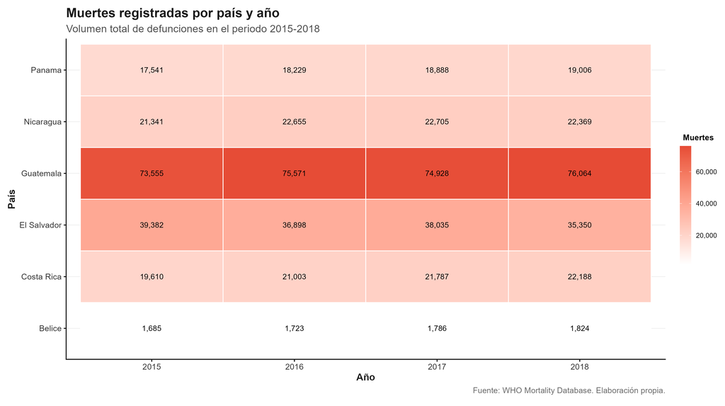

Figura 1: Muertes registradas por país y año, 2015-2018.

El mapa de calor de muertes por país y año muestra que la mortalidad observada no se distribuye uniformemente entre países. El mayor volumen aparece en Guatemala durante 2018, con 76,064muertes registradas. Además, Guatemala mantiene los valores más altos durante todo el periodo 2015-2018, lo que indica que buena parte del volumen absoluto de la base está concentrado en ese país.

El Salvador aparece como el segundo bloque de mayor magnitud, aunque con una reducción entre 2015 y 2018. En 2015 registra 39,382 muertes, mientras que en 2018 registra 35,350. Costa Rica, Nicaragua y Panamá presentan niveles intermedios, mientras que Belice aparece con un volumen mucho menor. Esta lectura debe hacerse con cautela, porque se están comparando conteos absolutos, no tasas ajustadas por población o exposición.

### Distribución de muertes por edad y causa

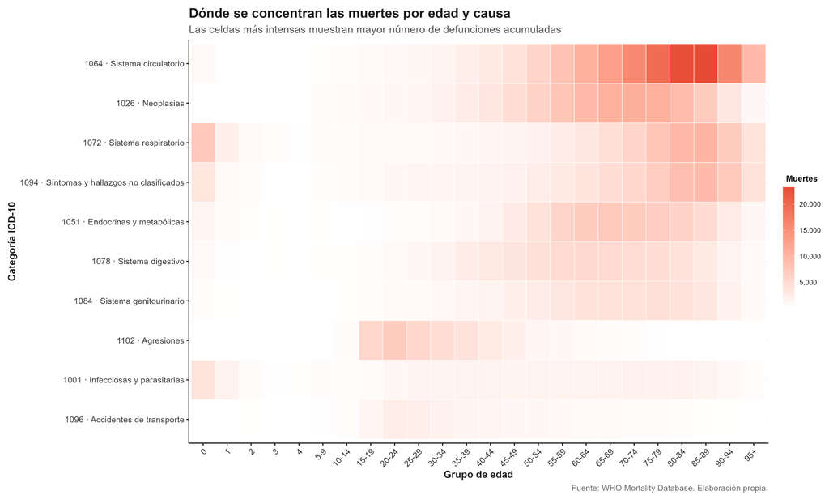

Figura 2: Concentración de muertes observadas por edad y causa.

El mapa de calor edad-causa muestra que las muertes se concentran principalmente en edades avanzadas. La categoría dominante es 1064 · Sistema circulatorio, que acumula 159,323 muertes en el periodo. La combinación edad-causa con mayor volumen fue 85-89 años y sistema circulatorio, con 23,235 muertes.

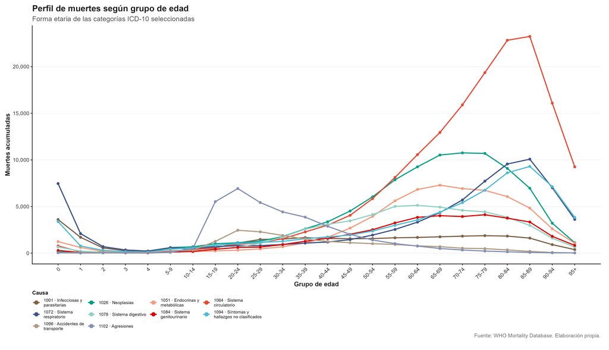

Figura 3: Perfil de muertes acumuladas según grupo de edad y causa.

El perfil etario refuerza esta lectura. Las enfermedades del sistema circulatorio aumentan de forma marcada a partir de edades adultas y alcanzan su máximo en edades avanzadas. Las neoplasias también presentan un crecimiento importante con la edad, aunque con una forma menos extrema que el sistema circulatorio. Las causas respiratorias y la categoría de síntomas y hallazgos no clasificados también ganan peso en edades avanzadas.

En contraste, 1102 · Agresiones presenta un patrón etario distinto. No domina en edades avanzadas, sino que se concentra principalmente en jóvenes y adultos jóvenes. Esto es relevante porque muestra que no todas las causas siguen la misma lógica demográfica, pues algunas son propias de edades avanzadas, mientras que otras se concentran en edades tempranas o productivas.

### Composición de las muertes a través de la edad

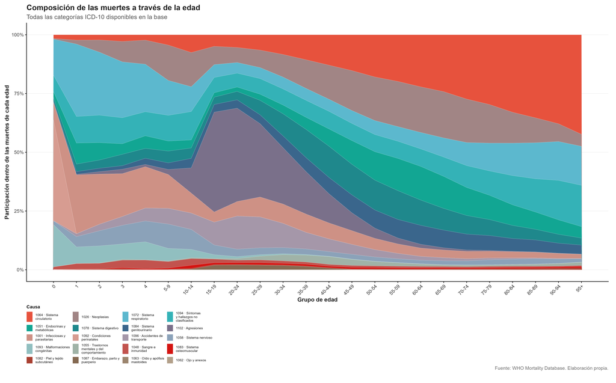

Figura 4: Composición de las muertes por grupo de edad considerando todas las categorías ICD-10.

El gráfico de composición por edad, construido con todas las categorías ICD-10 disponibles, permite ver cómo cambia la estructura causal de la mortalidad conforme avanza la edad. Este gráfico es especialmente importante porque no se limita a mostrar qué causa tiene más muertes en términos absolutos, sino qué proporción representa cada causa dentro de cada grupo etario.

En edades tempranas se observa una composición más fragmentada, con participación de causas respiratorias, infecciosas, congénitas, perinatales y categorías residuales. En edades jóvenes y adultas jóvenes aumentan las causas externas, especialmente agresiones y accidentes de transporte. En edades medias ganan presencia neoplasias, digestivas, genitourinarias y endocrinas. Finalmente, en edades avanzadas se vuelve dominante el sistema circulatorio.

### Estratos con mayor número de muertes observadas

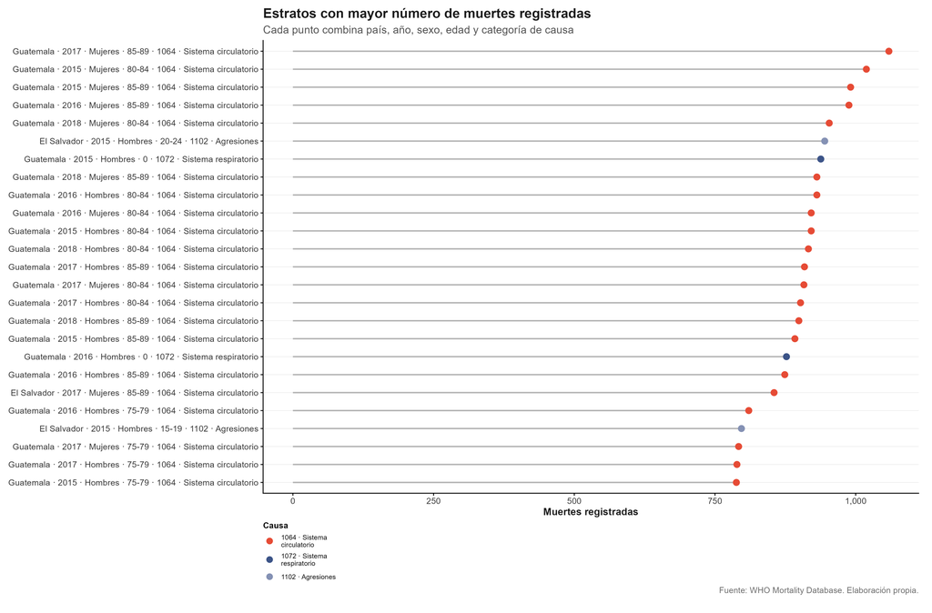

Figura 5: Estratos con mayor número de muertes registradas.

El gráfico de estratos con mayor número de muertes registradas muestra que los conteos más altos corresponden principalmente a Guatemala, edades avanzadas y sistema circulatorio. Destacan combinaciones como mujeres de 85-89 años y 80-84 años por sistema circulatorio. Esto confirma que la carga absoluta de mortalidad está dominada por causas crónicas en edades mayores.

Sin embargo, también aparece un estrato distinto: El Salvador, 2015, hombres de 20-24 años, agresiones, con 945 muertes observadas. Aunque el sistema circulatorio domina la mortalidad total, este estrato muestra que las agresiones tienen un peso considerable en hombres jóvenes, especialmente en El Salvador.

Esta diferencia es importante para el enfoque de decrementos múltiples, porque cada causa funciona como una salida distinta desde el estado vivo. Por tanto, una causa puede no dominar el total general, pero sí ser fundamental en ciertos grupos de edad y sexo.

### Análisis sobre excesos descriptivos

Para complementar el análisis de muertes observadas, se construyó una medida de exceso descriptivo. Para cada combinación de país, sexo, edad y causa, se compararon las muertes observadas de cada año contra la mediana interna del periodo 2015-2018:

$\text{Exceso}_t = \max(D_t - \widetilde{D}, 0)$

donde $(D_t)$ representa las defunciones observadas en el año $t$ y ($\widetilde{D}$) representa la mediana de defunciones del mismo estrato durante el periodo.

### Excesos por edad y causa

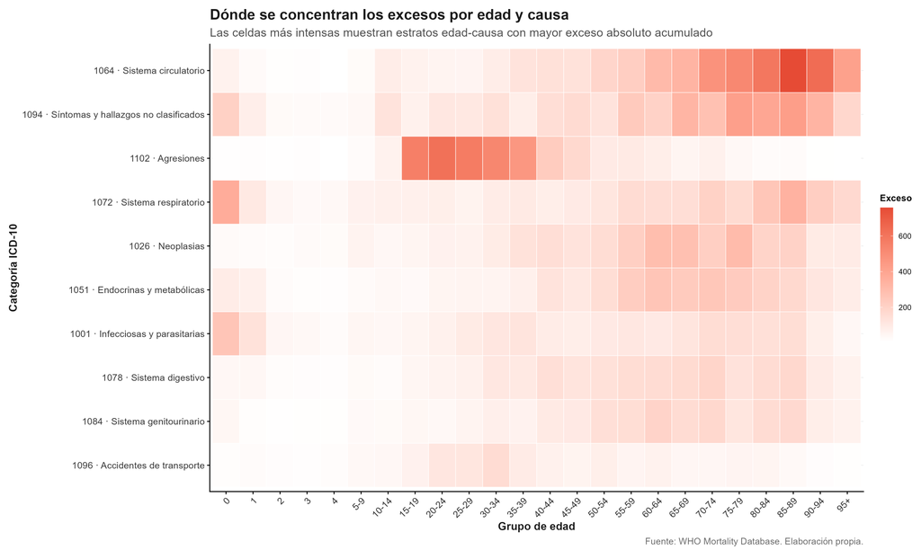

Figura 6: Concentración de excesos descriptivos por edad y causa.

Ahora note que la mayor combinación edad-causa por exceso fue 85-89 años y sistema circulatorio, con un exceso de 758 muertes. Esto indica que el sistema circulatorio no solo concentra el mayor número de muertes observadas, sino que también mantiene una desviación importante. También es importante ver como ahora esta más representada las agresiones en edades jóvenes y adultas jóvenes.

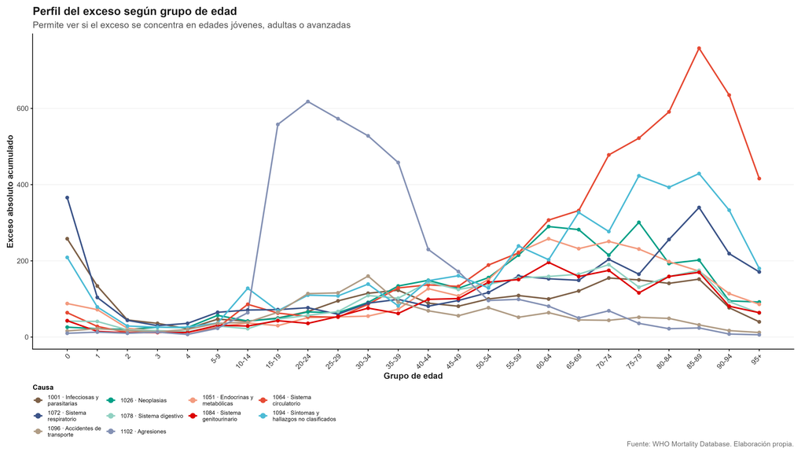

Figura 7: Perfil del exceso descriptivo según grupo de edad y causa.

El perfil del exceso muestra con claridad esta doble estructura. Por un lado, el sistema circulatorio tiene un exceso creciente en edades avanzadas, con un máximo alrededor de 85-89 años. Por otro lado, las agresiones presentan un exceso fuerte en edades jóvenes, especialmente entre 15 y 39 años.

### Estratos críticos de exceso

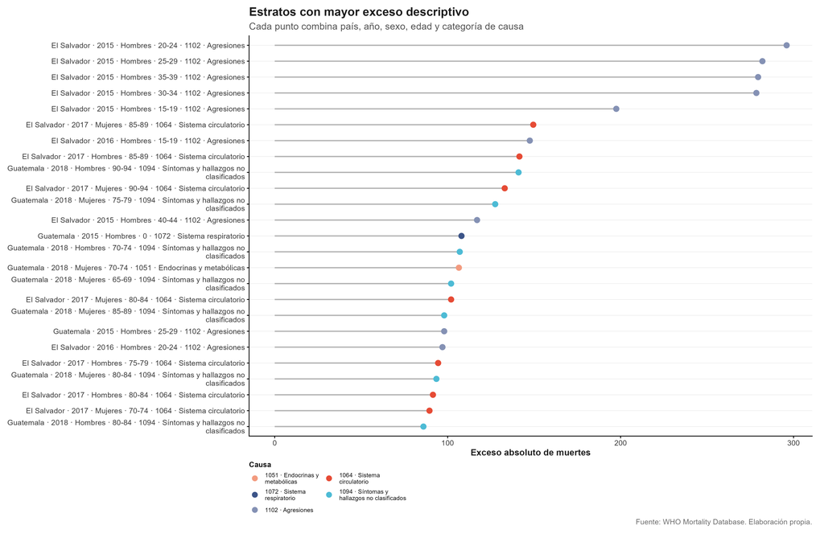

Figura 8: Estratos con mayor exceso descriptivo.

El hallazgo más fuerte del análisis de excesos aparece en el gráfico de estratos críticos. El mayor estrato individual por exceso fue El Salvador, 2015, hombres de 20-24 años, agresiones, con un exceso de 296 muertes. Además, los primeros lugares del ranking de exceso incluyen varios estratos similares: hombres salvadoreños en edades 15-19, 20-24, 25-29, 30-34 y 35-39 por agresiones.

Por tanto las agresiones en hombres jóvenes de El Salvador no solo son relevantes por volumen observado, sino porque también presentan desviaciones fuertes respecto a su propia mediana del periodo.

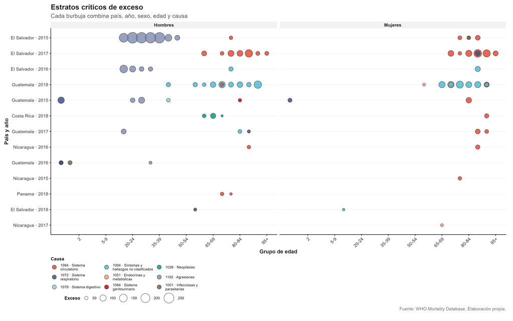

Figura 9: Estratos críticos de exceso por país, año, sexo, edad y causa.

También aparecen excesos importantes en edades avanzadas por sistema circulatorio, principalmente en El Salvador y Guatemala, así como excesos en la categoría de síntomas y hallazgos no clasificados. Esta última categoría debe interpretarse con precaución, ya que no representa una causa clínica específica, sino una clasificación residual que puede estar asociada a problemas de registro o falta de especificidad en la codificación de la muerte.

### Implicaciones para el modelo de decrementos múltiples

Este análisis exploratorio respalda la necesidad de modelar la mortalidad por causa manteniendo la estratificación por edad. Las causas no tienen la misma forma etaria, pues el sistema circulatorio domina en edades avanzadas, las agresiones en edades jóvenes, las neoplasias en edades adultas y mayores, y las respiratorias tienen presencia tanto en edades tempranas como avanzadas.

Para el cálculo posterior de probabilidades de decremento $_nq_x^{(c)}$., estos resultados sugieren que no basta con estimar una probabilidad agregada de muerte. Es necesario distinguir la causa $c$, el grupo de edad $x$, el país, el sexo y el año. Solo así se puede capturar adecuadamente la estructura de las distintas causas de muerte.

### Fichas de resultados

De manera introductoria aprovechando la depuración del conjunto de datos con sus respectivas etiquetas correspondientes a la ICD10, de forma descriptiva es de provecho introducir mediante un ejemplo, delimitando una cohorte de la muestra total, es posible generar una idea de la realización que tomará la estimación de $_nq_x^{(i)}$.

Considerar por ejemplo, las frecuencias de mortalidades para países que efectivamente superan la banda de tolerancia respecto a su cohorte.

```
        Pais icd10_code string number intervalo_edad freq_muerte mediana
1     Belice       1102      X     95        Deaths1          20     1.5
2     Belice       1102      X     95        Deaths1          39     1.5
3     Belice       1102      X     99        Deaths1          13     1.5
4 Costa Rica       1102      X     95        Deaths1          32     3.0
5 Costa Rica       1102      X     95        Deaths1         157     3.0
6 Costa Rica       1102      X     95       Deaths10          41     0.0
      media     banda desviacion intesity
1  5.136364  6.163636       18.5     18.5
2  5.136364  6.163636       37.5     37.5
3  5.136364  6.163636       11.5     11.5
4 10.274510 12.329412       29.0     29.0
5 10.274510 12.329412      154.0    154.0
6  1.705882  2.047059       41.0     41.0
```

Notar que se puede observar que para los países que presentaron una desviación mayor a la mediana respecto a la frecuencia de mortalidad se da que El Salvador presenta la mayor acumulación de perecimientos. Es más de tomar una tasa de mortalidad de perecimiento en El Salvador para la delimitaciones hechas en la cohorte obtiene la siguiente tasa de fallecimiento

```
[1] 0.9259515
```

### Ficha de resultado 1

**Nivel descriptivo:**

**Titular:** El Salvador refleja mayor índice de acumulación de tasa de mortalidad por asaltos en los Países Centroamericanos

**Nombre del hallazgo/resultado:** Concentración relativa de mortalidad por causa ICD10-1102 en población joven centroamericana

**Resumen en una oración:** El Salvador presentó la mayor acumulación relativa de mortalidad juvenil por asaltos entre 2015–2018.

**Método o análisis que lo produjo:** Análisis descriptivo de frecuencias relativas de mortalidad por causa específica, utilizando cohortes delimitadas por país, rango etario y clasificación ICD10. Se consideraron las observaciones correspondientes a la causa ICD10-1102 (asaltos) para edades enteras entre 0 y 25 años, durante el período 2015–2018, calculando posteriormente medidas de tendencia central y desviación respecto a la media para identificar países con intensidades de mortalidad superiores a la mediana observada.

**Nivel analítico:**

**Conexión con la pregunta de investigación:** El objetivo general del trabajo de investigación supone la estimación de las probabilidades de decremento por causas múltiples $_nq_x^{(i)}$ lo anterior estimado no es una probabilidad, si no una simple tasa, sin embargo supone un suministro válido para generar una idea intuitiva de cómo estará distribuída la probabilidad de decremento.

**Contraste con la literatura:** Este resultado no es una obscurencia con los elementos bibliográficos usados, es más una puntualización de una tasa relativa, en ningún momento se indica que es una probabilidad, debido a que como señalan las literaturas Multiple Decrement Models in Insurance y el trabajo *Inferring probabilities from rates: Extension to multiple decrement* el cálculo de una tasa no supone una referencia válida para estimar probabilidades pues desagregan la exposición.

**Lo que NO explica este resultado:** Claramente no refleja la naturaleza de la distribución general de $_nq_x^{(i)}$ por los señalamientos previamente hechos.

**Implicación para el siguiente paso:** Estimar con base en el material metodológico de *Inferring probabilities from rates: Extension to multiple decrement por parte de N. Keyfitz et al* las probabilidades de decremento no desagregadas del conjunto de datos.

### Ficha de resultado 2

**Nivel descriptivo:**

**Titular:**  
El exceso más fuerte no es donde hay más muertes.

**Nombre del hallazgo/resultado:**  
Diferencia entre concentración de muertes observadas y concentración de excesos descriptivos.

**Resumen en una oración:**  
Los mayores excesos aparecen en estratos muy específicos, no necesariamente en las causas con más muertes totales.

**Método o análisis que lo produjo:**  
Se compararon los estratos con mayor número de muertes registradas contra los estratos con mayor exceso descriptivo. El exceso se calculó comparando las muertes observadas de cada año contra la mediana del mismo estrato en el periodo 2015-2018.

**Evidencia:**  
La evidencia principal está en los gráficos de estratos con mayor número de muertes observadas y de estratos con mayor exceso descriptivo.

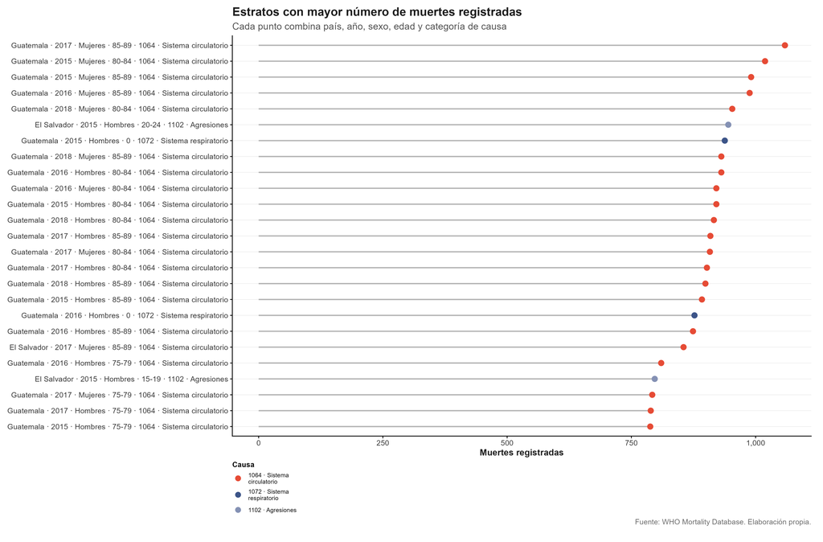

Figura 10: Estratos con mayor número de muertes registradas.

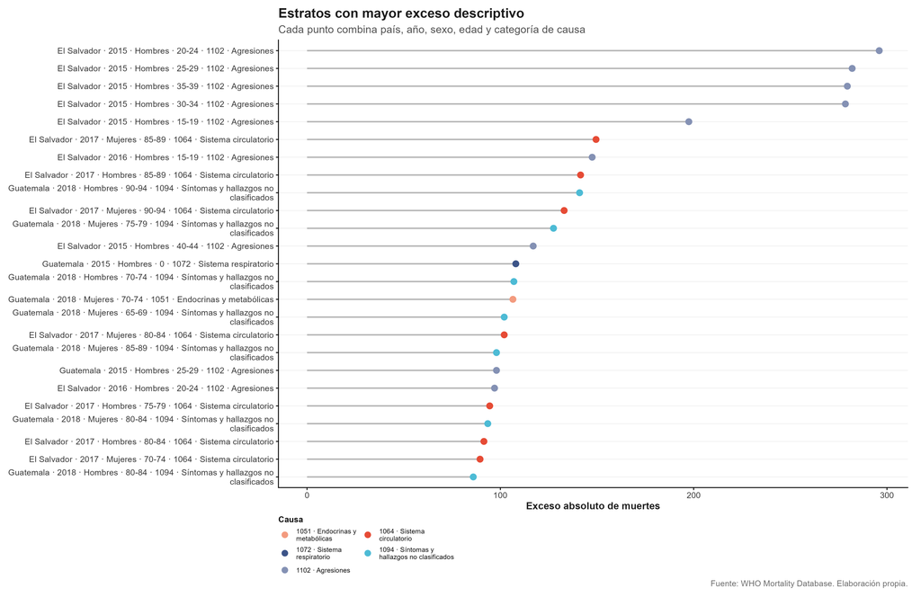

Figura 11: Estratos con mayor exceso descriptivo.

#### Nivel analítico:

Este resultado es más interesante que solo decir cuál causa mata más. En los datos observados, los estratos con más muertes se concentran sobre todo en edades avanzadas y en causas del sistema circulatorio, especialmente en Guatemala. Eso tiene sentido porque son grupos con mayor volumen de defunciones. Por otro lado el mayor estrato individual por exceso aparece en El Salvador, 2015, hombres de 20-24 años, causa 1102: agresiones, con un exceso de 296 muertes.

La diferencia importa porque muestra que el análisis de excesos no está repitiendo el análisis de volumen. Los conteos absolutos responden mucho al tamaño del país, la edad y la carga general de mortalidad. En cambio, el exceso descriptivo ayuda a detectar rupturas o desviaciones respecto al comportamiento típico del mismo grupo.

Por tanto hay que observar estratos donde una causa puede ser relativamente localizada, pero actuarialmente relevante por su variabilidad. En términos de decrementos múltiples, una causa puede no dominar el total de muertes, pero sí alterar de forma fuerte la probabilidad de salida en ciertos grupos de edad, sexo y país.

Este resultado no explica por qué ocurrió ese exceso en El Salvador ni permite atribuirlo directamente a un evento social específico. Tampoco prueba todavía un cambio estructural, porque esta etapa sigue siendo descriptiva. Lo que sí hace es señalar que los excesos pueden aparecer en zonas muy distintas a las que dominan el total de muertes.

### Ficha del resultado 3

**Titular:** Sistema circulatorio concentra la mortalidad en edades avanzadas.

**Nombre del hallazgo/resultado:** Hay una dominancia de las enfermedades del sistema circulatorio como causa de muerte en edades avanzadas.

**Resumen en una oración:** Las muertes por sistema circulatorio aumentan en edades avanzadas en Centroamérica.

**Método o análisis que lo produjo:** La creación de los gráficos muestra una tendencia de aumento en muertes por causa del sistema circulatorio. En especial, los gráficos de estratos con mayor número de muertes observadas y estratos críticos de exceso.

**Evidencia:** Los gráficos de calor muestran que la categoría ICD-10 1064 correspondiente al sistema circulatorio concentra la mayor cantidad de muertes observadas dentro del conjunto analizado. La combinación con mayor volumen fue el grupo de edad 85–89 años, acumulando aproximadamente 23,235 muertes. Además, el perfil etario evidencia un crecimiento sostenido de esta causa conforme aumenta la edad.

**Conexión con la pregunta de investigación:** Este hallazgo respalda la necesidad de modelar las probabilidades de decremento múltiple ${}_n q_x^{(c)}$ diferenciando explícitamente por edad y causa de muerte. El sistema circulatorio aparece como el principal decremento competitivo en edades avanzadas, por lo que su comportamiento influirá significativamente en la construcción de tasas centrales de mortalidad ${}_n m_x^{(c)}$ para adultos mayores.

**Contraste con la literatura:** El resultado coincide con la literatura revisada sobre mortalidad por causa y tablas de decrementos múltiples. Tanto Goerlich Gisbert (2012) en España, como Júlia Almeida Calazans y Bernardo Lanza Queiroz (2020), señalan que las enfermedades crónicas degenerativas, particularmente las cardiovasculares, dominan la mortalidad en edades avanzadas.

**Lo que NO explica este resultado:** El análisis descriptivo olvida diferenciar si el aumento observado responde únicamente al envejecimiento poblacional, diferencias en tamaño poblacional entre países o variaciones reales en la intensidad de mortalidad.

**Implicación para el siguiente paso:** Será necesario transformar los conteos observados en tasas centrales de mortalidad ${}_n m_x^{(c)}$ ajustadas por exposición, para posteriormente estimar probabilidades de decremento múltiple ${}_n q_x^{(c)}$. Además, este resultado sugiere que las causas circulatorias deberían modelarse separadamente en edades avanzadas debido a su peso dominante dentro de la estructura de mortalidad regional, un caso similar a las muertes por agresiones.

## 3.4. La imagen que cuenta la historia

Elegimos como imagen central el gráfico de composición de las muertes a través de la edad, porque es el que mejor conecta el análisis descriptivo con la lógica actuarial del proyecto.

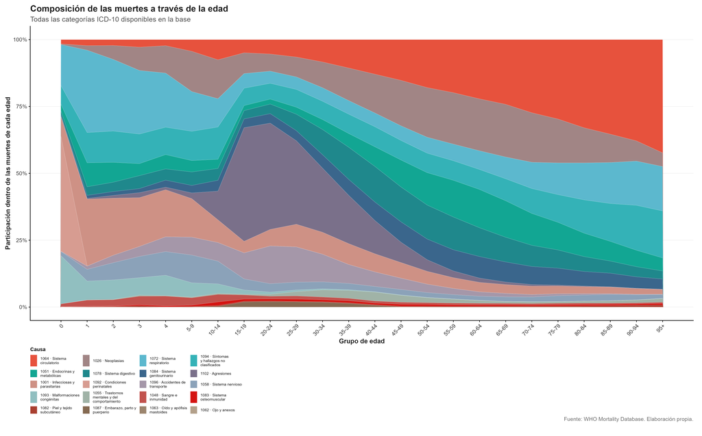

Figura 12: Composición de las muertes a través de la edad.

Esta imagen cuenta la historia porque va mostrando para cada edad, el cómo van variando de forma continua y pasando participación de uno a otro. En edades tempranas aparecen con más fuerza ciertas causas propias de esos grupos, es notable la gran proporción y posterior disminución de las causas perinatales. En edades jóvenes y adultas jóvenes ganan presencia algunas causas externas. Luego, conforme aumenta la edad, empiezan a tomar más espacio las enfermedades crónicas, especialmente las del sistema circulatorio.

Por eso esta figura funciona como puente entre el EDA y el modelo actuarial. Si las causas cambian tanto con la edad, entonces esta debe mantenerse como eje principal y cada causa debe leerse como una posible salida distinta desde el estado vivo, pero se deben de seguir considerando todas las otras variables como edad, sexo, país o año.

La imagen también deja claro qué se está omitiendo. No separa país, sexo ni año; tampoco muestra tasas ni probabilidades. Entonces no sirve para cerrar el análisis. Su papel es mostrar por qué necesitamos pasar de conteos observados a tasas y probabilidades de decremento por causa.

Por tanto esta imagen cuenta la historia porque muestra que el problema no es solamente cuántas personas mueren, sino cómo cambia la causa de muerte según la edad.

# 4. Arco narrativo del proyecto

Al explorar los datos, descubrimos que las probabilidades de decremento múltiple no pueden construirse únicamente a partir de frecuencias observadas de muerte, sino que requieren considerar la exposición de la población y la competencia entre distintas causas de salida del sistema, lo que nos obliga a repensar cómo abordaremos el problema.

# 5. Diario de aprendizaje

Durante estas semanas entendimos mucho mejor cómo se construyen realmente las probabilidades de decremento múltiple y que estas no salen directamente de observar muertes, sino de relacionar las frecuencias de fallecimiento con la exposición de la población. También aprendimos que la fuerza de mortalidad μx(x) puede aproximarse mediante tasas centrales de mortalidad bajo ciertos supuestos, algo que al inicio del proyecto no teníamos claro.

Por otra parte, nos dimos cuenta de que en R existen muy pocas herramientas preparadas específicamente para trabajar modelos actuariales de este tipo, por lo que gran parte del proceso debe programarse manualmente desde R base. Finalmente, comprendimos que uno de los mayores retos para trabajar tablas de vida en Centroamérica no es únicamente el modelado matemático, sino también la limitada disponibilidad y calidad de los datos demográficos y de mortalidad.

# Referencias

AAPC Thought Leadership Team. (2025, 3 de marzo). *What is ICD-10?* AAPC. https://www.aapc.com/resources/what-is-icd-10

Austin, P. C., Steyerberg, E. W., & Putter, H. (2021). Fine-Gray subdistribution hazard models to simultaneously estimate the absolute risk of different event types: Cumulative total failure probability may exceed 1. *Statistics in Medicine, 40*(19), 4200–4212. https://doi.org/10.1002/sim.9023

Baione, F., & Levantesi, S. (2014). A health insurance pricing model based on prevalence rates: Application to critical illness insurance. *Insurance: Mathematics and Economics, 58*, 174–184. https://doi.org/10.1016/j.insmatheco.2014.07.005

Baione, F., & Levantesi, S. (2018). Pricing critical illness insurance from prevalence rates: Gompertz versus Weibull. *North American Actuarial Journal, 22*(2), 270–288. https://doi.org/10.1080/10920277.2017.1397524

Bowers, N. L., Gerber, H. U., Hickman, J. C., Jones, D. A., & Nesbitt, C. J. (1997). *Actuarial mathematics* (2nd ed.). Society of Actuaries.

Calazans, J. A., & Queiroz, B. L. (2020). The adult mortality profile by cause of death in 10 Latin American countries (2000–2016). *Revista Panamericana de Salud Pública, 44*, e1. https://doi.org/10.26633/RPSP.2020.1

Deshmukh, S. (2012). *Multiple decrement models in insurance: An introduction using R*. Springer. https://doi.org/10.1007/978-81-322-0659-0

Dirgová, I., & Bilíková, M. (2014). Modelación actuarial del seguro de vida mediante modelos de decremento. *Journal of Applied Mathematics, Statistics and Informatics, 10*(1). https://doi.org/10.2478/jamsi-2014-0008

Fine, J. P., & Gray, R. J. (1999). A proportional hazards model for the subdistribution of a competing risk. *Journal of the American Statistical Association, 94*(446), 496–509. https://doi.org/10.1080/01621459.1999.10474144

Goerlich Gisbert, F. J. (2012). *Tablas de vida de decrementos múltiples: Mortalidad por causas en España (1975–2008)* (Documento de Trabajo No. 1/2012). Fundación BBVA.

Keyfitz, N., Preston, S. H., & Schoen, R. (1972). Inferring probabilities from rates: Extension to multiple decrement. *Scandinavian Actuarial Journal, 1972*(1), 1–13. https://doi.org/10.1080/03461238.1972.10404630

Li, J. (2019). *A multi-state model for pricing critical illness insurance products* [Master’s project, Simon Fraser University].

Lynch, S. M., & Brown, J. S. (2005). A new approach to estimating life tables with covariates and constructing interval estimates of life table quantities. *Sociological Methodology, 35*(1), 189–237. https://doi.org/10.1111/j.0081-1750.2006.00168.x

Macdonald, A. S. (1996). An actuarial survey of statistical models for decrement and transition data II: Competing risks, non-parametric and regression models. *British Actuarial Journal, 2*(2), 429–448. https://doi.org/10.1017/S1357321700003469

Macdonald, A. S., & Richards, S. J. (2025). On contemporary mortality models for actuarial use II: Principles. *British Actuarial Journal, 30*, e19. https://doi.org/10.1017/S1357321725000133

Makeham, W. M. (1860). On the law of mortality and the construction of annuity tables. *Journal of the Institute of Actuaries, 8*(6), 301–310. https://doi.org/10.1017/S204616580000126X

Manton, K. G., Woodbury, M. A., Stallard, E., Riggan, W. B., Creason, J. P., & Pellom, A. C. (1989). Empirical Bayes procedures for stabilizing maps of U.S. cancer mortality rates. *Journal of the American Statistical Association, 84*(407), 637–650. https://doi.org/10.1080/01621459.1989.10478816

Olivieri, A., & Pitacco, E. (2012). Life tables in actuarial models: From the deterministic setting to a Bayesian approach. *AStA Advances in Statistical Analysis, 96*, 127–153. https://doi.org/10.1007/s10182-011-0177-y

Orozco Cortés, J. S. (2023). *Estimación del riesgo de longevidad mediante distribuciones de supervivencia transmutadas* [Tesis de maestría, Universidad Nacional de Colombia].

Pasaribu, U. S., Husniah, H., Sari, R. R. K. N., & Yanti, A. R. (2019). Pricing critical illness insurance premiums using multiple state continuous Markov chain model. *Journal of Physics: Conference Series, 1366*(1), 012112. https://doi.org/10.1088/1742-6596/1366/1/012112

Patricio, S. C., & Missov, T. (2024). Makeham mortality models as mixtures: Advancing mortality estimations through competing risks frameworks. *Demographic Research, 51*, 595–624. https://doi.org/10.4054/DemRes.2024.51.18

Pitacco, E., Denuit, M., Haberman, S., & Olivieri, A. (2009). *Modelling longevity dynamics for pensions and annuity business*. Oxford University Press. https://doi.org/10.1093/oso/9780199547272.001.0001

Román Sánchez, Y. G., Sánchez Pérez, A. L., & Mendieta Zacarias, I. (2018). Mortalidad por causas en el estado de México, 2000 y 2015. *Novedades en Población, 14*(28), 64–78.

Schumacher, A. E., McCormick, T. H., Wakefield, J., Chu, Y., Perin, J., Villavicencio, F., Simon, N., & Liu, L. (2022). A flexible Bayesian framework to estimate age- and cause-specific child mortality over time from sample registration data. *The Annals of Applied Statistics, 16*(1), 124–143. https://doi.org/10.1214/21-AOAS1489

Scott, G. (2026, 24 de abril). *Variability: Definition in statistics and finance*. Investopedia. https://www.investopedia.com/terms/v/variability.asp

Society of Actuaries. (2016). *Experience study calculations*. Society of Actuaries.

Wikipedia. (s. f.). *Patrón (estructura).* Wikipedia. https://es.wikipedia.org/wiki/Patr%C3%B3n_(estructura)

Wolbers, M., Koller, M. T., Stel, V. S., Schaer, B., Jager, K. J., Leffondré, K., & Heinze, G. (2014). Competing risks analyses: Objectives and approaches. *European Heart Journal, 35*(42), 2936–2941. https://doi.org/10.1093/eurheartj/ehu131

World Health Organization. (2026). *About the WHO mortality database.* World Health Organization. https://platform.who.int/mortality/about/about-the-who-mortality-database

World Health Organization. (2026). *WHO Mortality Database.* World Health Organization. https://www.who.int/data/data-collection-tools/who-mortality-database

World Health Organization, Department of Data, Digital Health, Analytics and AI. (2026, 23 de febrero). *WHO Mortality Database documentation.* World Health Organization.

# Anexos

## Anexo 1: Fichas bibliográficas

### Mortalidad por causas en el estado de México, 2000 y 2015

**Título:** Mortalidad por causas en el estado de México, 2000 y 2015

**Autor(es):** Yuliana Gabriela Román Sánchez, Ana Laura Sánchez Pérez, Imelda Mendieta Zacarias

**Año:** 2018

**Nombre del tema:** Mortalidad por causas, esperanza de vida y tablas de vida de decrementos múltiples.

**Clasificación:** Metodológica, ya que el principal aporte para el proyecto no es solo el tema de mortalidad, sino el uso de tablas de vida de decrementos múltiples para estimar esperanza de vida según causa de muerte.

**Resumen en una oración:** El artículo estima cómo cambian las esperanzas de vida por causa de muerte.

**Argumento central:** El argumento central del artículo es que la mortalidad no debe estudiarse únicamente como un fenómeno general, sino diferenciada por causa de muerte, sexo y edad. Para esto, las autoras utilizan datos de estadísticas vitales, el Censo de Población 2000 y la Encuesta Intercensal 2015, y construyen tablas de vida de decrementos múltiples para siete grupos de causas de muerte. El artículo muestra que distintas causas generan efectos distintos sobre la esperanza de vida: por ejemplo, las causas externas tienen un impacto más fuerte en la reducción de la esperanza de vida que otras causas.

**Problemas con el argumento o tema:** El principal problema del tema es que la mortalidad por causas depende mucho de la calidad del registro de defunciones y de la correcta clasificación de la causa básica de muerte. Además, el artículo trabaja solo con dos años, 2000 y 2015, por lo que no permite observar una trayectoria anual continua. Otro problema es que las causas se agrupan en categorías amplias, lo cual facilita el análisis, pero puede ocultar diferencias importantes dentro de cada grupo.

**Conexión con mi proyecto:** Este artículo ofrece una forma concreta de analizar probabilidades de decremento por causa de muerte. Por lo que este artículo sirve como antecedente metodológico para construir tablas por edad, sexo, país y grupo de causa ICD-10. En particular, ayuda al uso de defunciones por causa, población expuesta al riesgo, edad, sexo, año y esperanza de vida según causa. En síntesis, su valor más importante es la forma de analizar los datos estadísticos después de haber sido ya obtenidos.

**Lo que NO dice el autor:** El artículo no responde cómo cambiarían los resultados si se utilizaran modelos probabilísticos o bayesianos para estimar la incertidumbre de las probabilidades de muerte. Tampoco desarrolla una comparación entre países, por lo que no permite saber si los patrones observados en el Estado de México se repiten en otros contextos latinoamericanos.

**Contraste con otra fuente:** Este artículo contrasta directamente con el trabajo de Goerlich (2012), incluso siendo mencionado varias veces en el mismo. Se observa que se complementan, siendo usado de referencia para el trabajo, pero además, resuelve el problema abierto de cómo se utilizarían y analizarían los modelos de decrementos múltiples en el contexto lationamericano, específicamente en el estado de México

**Evaluación de aplicabilidad (escala 1–5):** 4/5. La metodología es bastante aplicable porque trabaja con datos con los que ya se cuentan. Además, las tablas de vida de decrementos múltiples se relacionan directamente con el objetivo de analizar mortalidad por causas y se pensaban aplicar. Sin embargo, no es 5/5 porque el artículo se limita a un solo territorio, mientras que el presente proyecto busca hacer una comparación entre varios países y años.

**Pregunta que le haría al autor:** ¿Cómo cambiarían las estimaciones de esperanza de vida por causa si, además de las tablas de vida de decrementos múltiples, se incorporara un modelo estadístico que mida la incertidumbre de las probabilidades de muerte por edad, sexo y causa?

**Resumen argumentativo:** El problema que intenta resolver el artículo es que la mortalidad general puede ocultar diferencias importantes entre causas de muerte, grupos de edad y sexo. La solución propuesta funciona porque las tablas de vida de decrementos múltiples permiten separar el efecto de cada causa y traducirlo en esperanza de vida, que es un indicador más interpretable que una tasa aislada. Para el contexto de este proyecto, esta metodología es útil porque muestra cómo pasar de datos de defunciones a una estructura actuarial basada en probabilidades de muerte y cómo analizarlas. Sin embargo, el método tiene límites pues se busca comparar varios países y años, mientras que el artículo presenta resultados principalmente descriptivos de un país en dos años. Aun así, el artículo sirve como base para justificar que la mortalidad por causas puede estudiarse con herramientas actuariales y no solo con conteos o tasas generales. En nuestro trabajo se utiliza especialmente la idea de construir probabilidades de decremento por causa y comparar su efecto sobre la esperanza de vida.

### A New Approach to Estimating Life Tables with Covariates and Constructing Interval Estimates of Life Table Quantities

**Título:** A New Approach to Estimating Life Tables with Covariates and Constructing Interval Estimates of Life Table Quantities

**Autor(es):** Scott M. Lynch y J. Scott Brown

**Año:** 2005

**Nombre del tema:** Estimación bayesiana de tablas de vida con covariables e intervalos de incertidumbre

**Clasificación:** Metodológica. Se clasifica así porque el aporte principal del artículo es proponer un procedimiento estadístico para construir tablas de vida de decremento único, decrementos múltiples y multiestado incorporando covariables e intervalos de estimación.

**Resumen en una oración:** Estimar tablas de vida con covariables usando métodos bayesianos Monte Carlo por cadenas de markov (MCMC).

**Argumento central:** El argumento central del artículo es que las tablas de vida tradicionales son limitadas cuando se quiere incluir covariables y medir incertidumbre estadística al mismo tiempo. Los autores proponen un enfoque bayesiano basado en MCMC que primero estima un modelo de riesgo o supervivencia, luego genera distribuciones de probabilidades de transición, después usa esas probabilidades para construir tablas de vida y finalmente resume la distribución de cantidades como esperanza de vida o esperanza de vida activa.

**Problemas con el argumento o tema:** El principal problema que intenta resolver el artículo es que los métodos clásicos suelen construir tablas de vida separando los datos por grupos, por ejemplo sexo, raza o educación, lo cual puede producir muestras pequeñas e inestables. Además, muchos métodos permiten incluir covariables o construir intervalos de confianza, pero no ambas cosas al mismo tiempo. Una limitación del enfoque es que depende mucho de la especificación del modelo: si el modelo de riesgo, probit, Gompertz o Makeham está mal planteado, las probabilidades de transición y las esperanzas de vida también pueden quedar sesgadas. También requiere más conocimientos computacionales, porque usa simulación MCMC, convergencia, distribuciones posteriores e interpretación bayesiana.

**Conexión con mi proyecto:** Este artículo es relevante para el proyecto porque justifica el uso de un enfoque bayesiano para estimar probabilidades de decremento, como ${}_n q_x$ o ${}_n q_x^{(c)}$ , incorporando covariables como edad, sexo, año, país y causa de muerte. Su aporte principal no es solo construir tablas de vida, sino construir intervalos de incertidumbre para las probabilidades de transición y para cantidades derivadas de la tabla, lo cual permite comparar grupos sin depender únicamente de estimaciones puntuales. Esto es importante porque, en un análisis de mortalidad por causas, una diferencia entre países o entre causas puede parecer grande, pero debería evaluarse considerando la incertidumbre estadística.

**Lo que NO dice el autor:** El artículo no resuelve directamente cómo aplicar el método cuando solo se tienen datos agregados por edad, causa y año, en lugar de microdatos individuales o datos longitudinales. Tampoco se enfoca en América Latina ni en problemas de calidad del registro de defunciones, que sí serían importantes para un proyecto sobre mortalidad en Centroamérica. Además, aunque presenta ejemplos con mortalidad, causas de muerte y esperanza de vida activa, no desarrolla una guía sencilla para implementar el método en R con bases oficiales latinoamericanas.

**Contraste con otra fuente:** Este artículo complementa la ficha sobre Mortalidad por causas en el estado de México, 2000 y 2015. El artículo de Sánchez et al. (2018) usa tablas de vida de decrementos múltiples para estudiar diferencias de esperanza de vida según causa de muerte en un caso aplicado, mientras que Lynch y Brown proponen una metodología más general para incorporar covariables e intervalos de incertidumbre. En otras palabras, la fuente sobre el Estado de México muestra cómo aplicar tablas de decrementos múltiples a datos reales de mortalidad por causas; Lynch y Brown ofrecen una vía más avanzada para mejorar ese análisis mediante modelación estadística bayesiana.

**Evaluación de aplicabilidad (escala 1–5):** 4,5/5. La metodología es muy aplicable porque justifica el uso de un enfoque bayesiano para estimar probabilidades de decremento como ${}_n q_x$ o ${}_n q_x^{(c)}$, incorporando covariables como edad, sexo, país, año y causa de muerte. Su principal ventaja es que no produce sólo valores puntuales, sino intervalos de incertidumbre construidos a partir de simulaciones MCMC. Esto serviría para comparar causas o países sin asumir que toda diferencia observada es necesariamente significativa. La limitación principal es que el artículo trabaja principalmente con datos individuales o longitudinales, mientras que el proyecto usa datos agregados; aun así, la idea metodológica puede adaptarse a datos de defunciones y población expuesta.

**Pregunta que le haría al autor:** ¿Qué modelo bayesiano recomendaría para estimar ${}_n q_x^{(c)}$ e intervalos de incertidumbre usando datos agregados de mortalidad por causa, edad, sexo, país y año?

**Resumen argumentativo:** El problema que resuelven Lynch y Brown es que las tablas de vida tradicionales no incorporan fácilmente covariables ni intervalos de incertidumbre para las cantidades estimadas. Su propuesta funciona porque usa MCMC para generar muchas posibles realizaciones de los parámetros del modelo y, con cada una de ellas, calcula probabilidades de transición. En el contexto del proyecto, esto permite estimar no solo ${}_n q_x$ o ${}_n q_x^{(c)}$, sino también un intervalo para esas probabilidades. Esto es importante porque las probabilidades de muerte por causa pueden variar por edad, sexo, país y año, y esa variabilidad debe reflejarse en el análisis. El enfoque bayesiano permite decir si una diferencia entre grupos parece consistente o si podría explicarse por la incertidumbre de los datos. Usaremos este artículo como respaldo metodológico para justificar la estimación de intervalos de incertidumbre en probabilidades de decremento por causa de muerte.

### Pricing Critical Illness Insurance from Prevalence Rates: Gompertz versus Weibull

**Título:** Pricing Critical Illness Insurance from Prevalence Rates.

**Autor(es):** Fabio Baione & Susanna Levantesi.

**Año:** 2018

**Nombre del tema:** Cálculo de primas de seguros de enfermedades críticas (CI) a partir de tasas de prevalencia, comparando los modelos de Gompertz y Weibull.

**Clasificación:** Se clasifica como Metodológica, se propone un procedimiento para estimar intensidades de transición y probabilidades a partir de datos de prevalencia, aplicándolo a datos reales de una base de Italia y comparando modelos clásicos de mortalidad.

**Resumen en una oración:** Modelo CI basado en prevalencia que compara Gompertz y Weibull en datos de Italia.

**Argumento central:** Plantea que, en ausencia de datos de incidencia, las probabilidades de transición en un modelo de Markov de varios estados se puede estimar a partir de tasas de prevalencia combinadas con mortalidad, usando funciones paramétricas como Gompertz o Weibull para modelar las intensidades de transición ${}^{(c)}\mu_x$ y evaluando cual reproduce mejor los resultados esperados y variaciones en ${}_n q_x^{(c)}$ y las primas $P_x^{SA}.$

**Problemas con el argumento o tema:** El modelo introduce incertidumbre adicional, pues omite totalmente el uso de datos directos de incidencia de enfermedades. Además, no aborda la aplicación del modelo en contexto con datos agregados de mortalidad por causa, como en la base de datos de WHO.

**Lo que NO dice el autor:** El documento no considera el uso de datos de mortalidad por causa, ni mucho menos analiza la construcción de ${}_n q_x^{(c)}$ partiendo de la discretización de los datos mediante las mortalidades centrales.

**Contraste con otra fuente:** El trabajo de Baione & Levatntesi se complementa con el de Jingdan Li (2019). Mientras Li desarrolla el modelo multiestado desde una perspectiva teórica y lo aplica a datos de incidencia y prevalencia, Baione y Levantesi proponen un enfoque más empírico basado en datos reales, mostrando cómo estimar intensidades a partir de prevalencia y comparar los modelos clásicos. Por ende, ambos artículos aportan una visión completa y complementada: Li proporciona el marco más conceptual del concepto del modelo de varios estados, mientras que Baione y Levantesi permiten evaluar su implementación práctica y la robustez de los modelos utilizados.

**Evaluación de aplicabilidad (escala 1–5):** 3. El enfoque es aplicable en términos de metodología, pues fundamenta que se pueden comparar los modelos paramétricos utilizando bases de datos reales. Sin embargo, se limita debido al factor de los grupos de edad de este proyecto.

**Pregunta que le haría al autor:** ¿Cómo varían los resultados del modelo si, en lugar de utilizar tasas de prevalencia, se emplearan directamente tasas de mortalidad por causa derivadas de una base de datos como la de la WHO?

**Resumen argumentativo:** El artículo aborda el problema de estimar primas de seguros de enfermedades críticas cuando carece de datos de incidencia, proponiendo únicamente la aplicación mediante el uso de tasas de prevalencia. Esto permite reconstruir las intensidades de transición y calcular ${}_n q_x^{(c)}$ y $P_x^{SA}.$ No obstante, si la base de datos carece de información suficiente, los parámetros pueden sobreestimar o calcular erróneamente las intensidades de transición para el cálculo de primas. Para efectos de este proyecto, el documento muestra cómo construir de manera empírica modelos paramétricos como Gompertz y Weibull. Por lo tanto, resulta útil tomar en cuenta esta otra forma de construir la tasa de decrementos múltiples, puesto que en este artículo se carece de tasas de incidencia de enfermedades, como ocurre con la base a utilizar en este proyecto.

### Multiple Decrement Models in Insurance: An Introduction Using R

**Título:** Multiple Decrement Models in Insurance: An Introduction Using R

**Autor(es):** Shailaja Deshmukh.

**Año:** 2012.

**Clasificación:** Teórica, porque desarrolla la formulación matemática del modelo de decrementos múltiples y muestra su implementación práctica mediante ejercicios y manejo de datos en R, sin centrarse en desarrollo teórico no antes visto.

**Resumen en una oración:** Fundamenta matemáticamente los decrementos múltiples, las pensiones y su implementación práctica en R.

**Argumento central:** El documento establece que las probabilidades de decremento múltiple pueden derivarse a partir de intensidades de transición mediante expresiones continuas, muestra que las tasas centrales de mortalidad ${}_n m_x^{(c)}$ pueden interpretarse como promedios de dichas intensidades ${}^{(c)}\mu_x$ al igual que la ley Fabio Baione & Susanna Levantesi. Facilita también una serie de ejercicios y ejemplos donde implementa estos modelos a bases de datos simples.

**Problemas con el argumento o el tema:** El documento no aborda el uso de bases de datos reales ni el tratamiento de datos agregados como los grupos de edad obtenidos de la WHO, ni incluye herramientas computacionales avanzadas o paquetes especializados, pues utiliza R base. Su enfoque es principalmente aplicado mediante ejemplos simples, por lo que limita los análisis e interpretaciones de casos con mayores bases. Además, su objetivo es construir las bases de la modelación de decrementos múltiples, dejando de lado el uso de leyes como la de Gompertz o Weibull.

**Conexión con mi proyecto:** El libro fundamenta la base matemática que justifica el uso de ${}_n m_x^{(c)}$ y ${}_n q_x^{(c)}$ para obtener las tasas de decrementos múltiples ${}_n q_x^{(c)}$ de manera computacional para Centroamérica, lo cual constituye la parte metodológica del proyecto. También muestra una serie de pasos para trabajar con estos modelos en R.

**Contraste con otra fuente:** Este documento complementa los trabajos de Jingdan Li (2019). Mientras Li desarrolla y aplica modelos multiestados con datos reales y comparaciones paramétricas, este documento proporciona el fundamento matemático que permite entender el proceso computacional que hay detrás de ello. En conjunto, las fuentes cubren la construcción de ${}_n q_x^{(c)}$ y la implementación de ello en R.

**Evaluación de aplicabilidad:** 4, es una guía altamente aplicable, pues proporciona directamente las herramientas computacionales para construir ${}_n q_x^{(c)}$ a partir de bases de datos, necesario para la metodología del proyecto.

**Pregunta que le haría al autor:** ¿Cómo se podría extender este enfoque computacional para incorporar modelos paramétricos de intensidades (como Gompertz o Weibull) en el cálculo de probabilidades de decremento con datos agregados?

**Resumen argumentativo:** Deshmukh busca modelar las probabilidades de decrementos múltiples a partir de intensidades de transición en un modelo multiestado continuo. Esta formulación la aplica de manera computacional aplicando fórmulas matemáticas en R base. Si bien no se dispone de bases de datos reales, su implementación se fundamenta para entender el proceso programado de ${}_n q_x^{(c)}$ en un lenguaje informático. Dado el contexto de este proyecto, proporciona también la base teórica que justifica la construcción de tasas centrales de mortalidad ${}_n m_x^{(c)}$ necesarias para la discretización de los datos y así construir ${}_n q_x^{(c)}$. Por ende, el libro resulta como soporte fundamental para la correcta aplicación del modelo de decrementos múltiples y la construcción de las tablas de mortalidad.

### Empirical Bayes Procedures for Stabilizing Maps of U.S. Cancer Mortality Rates.

**Título:** Empirical Bayes Procedures for Stabilizing Maps of U.S. Cancer Mortality Rates.

**Autor(es):** Kenneth G. Manton, Max A. Woodbury, Eric Stallard, Wilson B. Riggan, John P. Creason y Alvin C. Pellom.

**Año:** 1989.

**Nombre del tema:** Estimación empírico-bayesiana de tasas de mortalidad por cáncer usando conteos de muertes, exposición en personas-año y modelos Poisson-Gamma.

**Clasificación:** Metodológica.  
Se clasifica así porque sirve para justificar un modelo bayesiano aplicado a tasas de mortalidad con datos agregados de defunciones y exposición.

**Resumen en una oración:**  
Manton et al. (1989) fundamentan el enfoque bayesiano Poisson-Gamma para estimar tasas de mortalidad por causa.

**Argumento central:**  
Manton et al. (1989) parten del problema de que las tasas de mortalidad observadas pueden variar demasiado cuando se calculan en poblaciones pequeñas o con pocas defunciones. Por eso, proponen estabilizar esas tasas usando información adicional del conjunto de áreas.

La parte más útil para nuestro proyecto es que los autores trabajan explícitamente con muertes y exposición. En su planteamiento, $Y_{ij}$ representa el número de muertes en la celda $(i,j)$, $n_{ij}$ representa las personas-año de exposición y $\mu_{ij}$ representa la tasa verdadera de mortalidad en la celda $(i,j)$. A partir de esto, el conteo de muertes puede aproximarse mediante un modelo Poisson:

$$Y_{ij} \mid \mu_{ij} \sim \operatorname{Poisson}(n_{ij}\mu_{ij})$$

Además, los autores asignan una distribución Gamma a la tasa $\mu_{ij}$ y señalan que esta familia es conjugada con la distribución Poisson. Por tanto, la distribución posterior pertenece nuevamente a la familia Gamma. En términos generales, la actualización bayesiana consiste en sumar las muertes observadas al parámetro de forma y la exposición al parámetro de tasa. Esta es la idea central que interesa para el proyecto.

**Problemas con el argumento o el tema:**  
El artículo no está escrito para decrementos múltiples actuariales, sino para mortalidad por cáncer. Por eso, no desarrolla directamente la construcción de probabilidades de decremento por causa ni trabaja con modelos actuariales de causas competitivas. Su aporte está más relacionado con la estabilización bayesiana de tasas de mortalidad a partir de conteos de muertes y exposición.

**Conexión con mi proyecto:**  
Este artículo es el respaldo más cercano para el componente bayesiano del proyecto. En la *WHO Mortality Database* se tendrán defunciones por causa y una exposición o población aproximada. La adaptación al proyecto sería:

$$D_{x,t}^{(c)} \mid \mu_{x,t}^{(c)} \sim \operatorname{Poisson}(E_{x,t}\mu_{x,t}^{(c)})$$

donde $D_{x,t}^{(c)}$ representa las defunciones observadas por causa $c$, $E_{x,t}$ representa la exposición o personas-año en riesgo y $\mu_{x,t}^{(c)}$ representa la tasa de mortalidad por causa $c$.

Luego, se asume una previa Gamma para la tasa de mortalidad por causa:

$$\mu_{x,t}^{(c)} \sim \operatorname{Gamma}(\alpha,\beta)$$

Por conjugación, la distribución posterior queda:

$$\mu_{x,t}^{(c)} \mid D_{x,t}^{(c)}, E_{x,t}
\sim
\operatorname{Gamma}(\alpha + D_{x,t}^{(c)}, \beta + E_{x,t})$$

Manton et al. (1989) no escriben esta última fórmula exactamente con la notación del proyecto, pero sí utilizan la misma estructura conjugada Poisson-Gamma. Por eso, el artículo sirve como base para justificar la estimación bayesiana de tasas de mortalidad por causa antes de transformarlas en probabilidades de decremento.

**Lo que NO dice el autor:**  
El artículo no desarrolla modelos de decrementos múltiples. Tampoco transforma directamente tasas por causa en probabilidades actuariales de decremento. Su aporte está en la estimación estabilizada de tasas de mortalidad a partir de muertes y exposición, no en la construcción completa de tablas de vida de decrementos múltiples.

**Contraste con otra fuente:**  
Olivieri y Pitacco se usarán como respaldo actuarial para la parte de conteos de sobrevivientes y defunciones. Para el componente bayesiano se usará principalmente Manton et al. (1989), pues su formulación se acerca más a lo que necesita este proyecto: muertes observadas, exposición en personas-año, tasa de mortalidad y estructura Poisson-Gamma. A diferencia de Olivieri y Pitacco, Manton et al. no dependen de una tabla actuarial previa, sino que trabajan directamente con conteos observados y exposición.

**Evaluación de aplicabilidad:**  
**5/5.** La aplicabilidad es alta para la parte bayesiana del proyecto. A diferencia de Olivieri y Pitacco en *Life tables in actuarial models: from the deterministic setting to a Bayesian approach*, este artículo no depende de una tabla actuarial previa, sino que trabaja directamente con conteos de muertes y exposición. Esto se ajusta mejor a la estructura de la *WHO Mortality Database*, donde se tendrán defunciones por causa, edad, sexo, país y año.

**Pregunta que le haría al autor:**  
¿Cómo adaptaría su procedimiento si las celdas no fueran condado y edad, sino país, sexo, año, grupo de edad y causa de muerte?

**Resumen argumentativo:**  
Manton et al. (1989) es una fuente clave para el proyecto porque formula de manera aplicada la estructura que se necesita para la parte bayesiana: las muertes se modelan como conteos Poisson cuya media depende de la exposición y de una tasa de mortalidad, mientras que la tasa se modela con una distribución Gamma. Aunque el artículo trabaja con mapas de cáncer en Estados Unidos y no con decrementos múltiples, su estructura estadística se adapta bien a datos agregados como los de la *WHO Mortality Database*. Su principal aporte será justificar la estimación bayesiana de tasas de mortalidad por causa antes de convertirlas en probabilidades de decremento. Por eso, esta fuente no será usada como fundamento actuarial de los decrementos múltiples, sino como respaldo estadístico para la estabilización bayesiana de las tasas de mortalidad por causa.

### Life tables in actuarial models: from the deterministic setting to a Bayesian approach

**Título:** Life tables in actuarial models: from the deterministic setting to a Bayesian approach.

**Autor(es):** Annamaria Olivieri y Ermanno Pitacco.

**Año:** 2011.

**Nombre del tema:** Uso de tablas de vida en modelos actuariales, pasando desde un enfoque determinístico clásico hacia un enfoque estocástico y bayesiano de la mortalidad.

**Clasificación:** Metodológica.  
Se clasifica así porque sirve principalmente para entender cómo una tabla de vida puede pasar de usarse como objeto determinístico a usarse dentro de un modelo con incertidumbre para una cartera de vidas.

**Resumen en una oración:**  
Olivieri y Pitacco (2011) muestran cómo tratar sobrevivientes y defunciones como variables aleatorias dentro de modelos actuariales de mortalidad.

**Argumento central:**  
El punto inicial de Olivieri y Pitacco (2011) es que el modelo actuarial clásico, aunque utiliza probabilidades como ${}_t p_x$ o $q_x$, sigue siendo determinístico porque esas probabilidades se tratan como conocidas y solo se usan para calcular valores esperados. Es decir, la tabla de vida no se cuestiona, sino que se toma como dada.

Luego, el número de sobrevivientes ya no se interpreta únicamente como su valor esperado, sino como una variable aleatoria. En particular, si una cohorte inicia con $n_{x_0}$ personas, el número de sobrevivientes a la edad $x_0+t$ se puede modelar como:

$$N_{x_0+t} \sim \operatorname{Binomial}(n_{x_0}, {}_t p_{x_0})$$

Las defunciones entre las edades $x_0+t$ y $x_0+t+1$ se definen como:

$$D_{x_0+t} = N_{x_0+t} - N_{x_0+t+1}$$

Luego, condicional al número de vivos al inicio del intervalo, las defunciones se pueden modelar como binomiales y aproximarse mediante una distribución Poisson:

$$D_{x_0+t} \mid N_{x_0+t}
\sim
\operatorname{Poisson}(N_{x_0+t}q_{x_0+t})$$

Esta parte es la más útil del artículo para el proyecto, porque justifica trabajar con conteos de defunciones como variables aleatorias y no solo como proporciones observadas.

**Problemas con el argumento o el tema:**  
El artículo está pensado para rentas vitalicias y mortalidad total, no para decrementos múltiples por causa. Además, la parte bayesiana es menos directa para este proyecto, porque no estima desde cero una tasa por causa, sino que supone que ya existe una tabla de vida proyectada disponible. A partir de esa tabla, los autores introducen un parámetro $Z$ para corregir la mortalidad esperada, que es el que se estima mediante una distribución previa y una posterior.

**Conexión con mi proyecto:**  
El artículo sirve principalmente para justificar que las defunciones observadas pueden tratarse como conteos aleatorios asociados a una exposición y a una tasa de mortalidad. Esto es útil para el proyecto porque permite pasar de una lectura determinística de las tablas de vida a una interpretación donde los conteos de muertes tienen variabilidad estadística.

**Lo que NO dice el autor:**  
El artículo no trabaja con decrementos múltiples por causa. Tampoco estima directamente tasas por causa a partir de datos observados de defunciones y exposición.

**Contraste con otra fuente:**  
Olivieri y Pitacco se usarán como respaldo actuarial para la parte de conteos de sobrevivientes y defunciones. Para el componente bayesiano se usará principalmente Manton et al. (1989), pues su formulación se acerca más a lo que necesita este proyecto: muertes observadas, exposición en personas-año, tasa de mortalidad y estructura Poisson-Gamma. A diferencia de Olivieri y Pitacco, Manton et al. trabajan directamente con conteos de muertes y exposición, sin depender de una tabla actuarial previa.

**Evaluación de aplicabilidad:**  
**3/5.** La aplicabilidad es baja-media para el enfoque bayesiano, porque el artículo ajusta una tabla previa y no estima directamente tasas por causa desde datos observados. Sin embargo, su aplicabilidad es alta para justificar el paso desde una tabla de vida determinística hacia un modelo donde sobrevivientes y defunciones se tratan como variables aleatorias. Por eso, la fuente será útil como respaldo actuarial para la parte de conteos, pero no como base central del componente bayesiano del proyecto.

**Pregunta que le haría al autor:**  
¿Cómo cambiaría el modelo si no se tuviera una tabla proyectada previa y solo se contara con defunciones y exposición por edad, año, sexo y causa?

**Resumen argumentativo:**  
Olivieri y Pitacco (2011) sirven como respaldo actuarial para pasar de una tabla de vida determinística a un modelo donde sobrevivientes y defunciones se tratan como variables aleatorias. Su aporte principal para el proyecto es justificar el uso de conteos de defunciones asociados a una exposición, especialmente mediante una aproximación Poisson. Sin embargo, el artículo no trabaja con decrementos múltiples por causa ni estima directamente tasas por causa desde datos observados. Por eso, será útil como apoyo metodológico para la parte de conteos y mortalidad aleatoria, pero no como fuente central del componente bayesiano del proyecto. Para esa parte, Manton et al. (1989) resulta más adecuado, porque trabaja directamente con muertes observadas, exposición y tasas de mortalidad mediante una estructura Poisson-Gamma.

### Inferring probabilities from rates: Extension to multiple decrement

**Título:** Inferring probabilities from rates: Extension to multiple decrement.

**Autor(es):** Nathan Keyfitz, Samuel H Preston y Robert Schoen.

**Año:** 1972.

**Nombre del tema:** Inferir probabilidades a partir de proporciones de muertes debido a causas segregadas en un conjunto de datos agregados.

**Clasificación:** Metodológica, debido a que el trabajo se centra en describir cómo obtener probabilidades de decremento múltiple mediante proporciones dadas de muerte.

**Resumen en una oración:** El artículo muestra cómo convertir tasas y proporciones de mortalidad en probabilidades de decremento múltiples consistentes.

**Argumento central:** El determinar la probabilidad de decremento ${}_n q_x^{(c)}$ no suele ser una tarea fácil como se puede creer, más allá de observar proporciones por causa de muerte, debido a que esta misma proporción observada de muertes por causa no depende únicamente de las tasas relativas de mortalidad entre causas, sino también de la estructura etaria y dinámica de la población, lo cual impide interpretar directamente dichas proporciones como probabilidades de decremento. En este sentido resulta indispensable realizar una traducción certera a probabilidades dentro de un modelo de decrementos multiestado, en el que se requiere considerar el tiempo de exposición, la competencia entre causas para salir del modelo y la variación de la cantidad de población en el intervalo temporal estudiado.

**Problemas con el argumento o el tema:** El enfoque requiere supuestos fuertes como la constancia de la fuerza de mortalidad dentro de los intervalos de edad y un crecimiento poblacional exponencial, lo cual puede no cumplirse en datos reales; además, la metodología depende de información de exposición que no siempre está disponible con precisión.

**Conexión con mi proyecto:** El trabajo de investigación supone un suministro bastante significativo con el proyecto propuesto, debido a que sustancialmente nos enfrentamos a un mismo dilema, es decir, la pregunta de ¿Cómo transformar proporciones observadas de muerte a probabilidades dentro de un modelo multiestado? Ateniéndonos al lineamiento metodológico estipulado por los autores, se podrá implementar una estrategia sensata para realizar una traducción adecuada de las frecuencias de muerte observadas para los diferentes intervalos de edad.

**Lo que no dice el autor:** ¿Cómo segregar intervalos de edad para conteos de decrementos hechos en bandas etarias?

**Contraste con otra fuente:** En relación con el trabajo articulado por Goerlich (2012) en *Tablas de vida de decrementos múltiples*, este material supone un suministro complementario adecuado debido a que Goerlich usa tablas de vida para describir probabilidades por causa, mientras que Keyfitz et al. se enfocan en cómo construir esas probabilidades correctamente a partir de las tasas observadas, es decir desde el planteamiento de Goerlich ya se asume la existencia ${}_n q_x^{(c)}$ para la construcción de las tablas de vida, mientras que Keyfitz et al. en un nivel anterior nos dice cómo construirlos.

**Evaluación y aplicabilidad:** 4.5, la investigación indica de qué manera calcular probabilidades de decremento asociadas a una causa $c$, ${}_n q_x^{(c)}$, a partir de una proporción de muertes

$$\frac{D_x^{(c)}}{D_x}$$

donde $D_x^{(c)}$ denota la cantidad de muertes asociada a una causa $c$ y $D_x$ denota la cantidad de muertes general en el intervalo de edades $]x,x+n[$. Pero no describe cómo segregar los intervalos de edad correspondientes.

**Pregunta que le haría al autor:** ¿Cómo adaptar la metodología propuesta cuando los datos disponibles están agregados en bandas etarias y no se dispone de exposición exacta ${}_n P_x$ para cada subgrupo?

**Resumen argumentativo:** El artículo delimita una metodología para abordar el problema de una traducción adecuada de proporciones de muerte asociadas a diferentes causas a probabilidades de decrementos por causas segregadas de muertes.

El aporte es sustancialmente significativo debido a que la solución planteada ofrece una ruta específica de acción para manipular un conjunto de datos agregados por frecuencias de fallecimiento.

En el contexto del proyecto, este enfoque resulta altamente útil porque proporciona una base formal para transformar los datos de mortalidad por causa provenientes de la base de la OMS en probabilidades de decremento comparables entre grupos de edad. En particular, se utilizará la idea de pasar de tasas centrales de mortalidad a probabilidades mediante supuestos de constancia en los intervalos, lo cual permitirá construir tablas de vida de decrementos múltiples.

### Pricing Critical Illness Insurance Premiums Using Multiple State Continuous Markov Chain Model

**Título:** Pricing Critical Illness Insurance Premiums Using Multiple State Continuous Markov Chain Model.

**Autor(es):** U. S. Pasaribu et al.

**Año:** 2019.

**Nombre del tema:** Tarificación de primas, en donde se asume una fuerza de mortalidad constante en un contexto multiestado.

**Clasificación:** Metodológica, pues presenta una metodología compatible con la suposición de fuerza de mortalidad constante dentro de un intervalo de edad, en un modelo markoviano continuo multiestado, lo cual sería fácilmente extrapolable a un contexto de decrementos múltiples como el que se trabajará, al ser este un caso particular del modelo multiestado.

**Resumen en una oración:** Pasaribu et al. sirve como antecedente secundario sobre suma de intensidades.

**Argumento central:** El artículo plantea que la evolución de un asegurado puede representarse mediante estados de salud y muerte, por ejemplo sano, enfermo crítico, muerto por enfermedad crítica y muerto por otras causas. Utilizan intensidades de transición por grupo etario y combinan las intensidades de salida desde un mismo estado para calcular probabilidades de transición y primas.

**Problemas con el argumento o el tema:** El principal problema es que el artículo no explica con suficiente detalle cómo obtiene las intensidades numéricas que utiliza. Aunque menciona fuentes como CMI Working Paper 50 y trabajos asociados a Gutiérrez y Macdonald, no reconstruye claramente el paso desde esas tasas externas hasta su tabla final de intensidades. Además, el modelo está pensado para seguros de enfermedad crítica y contiene estados intermedios de enfermedad que no se observan en la WHO Mortality Database.

**Conexión con mi proyecto:** Sirve únicamente como apoyo conceptual para entender que varias intensidades de salidas desde un mismo estado pueden combinarse en una intensidad total de salida. No obstante, el modelo del proyecto no se apoyará principalmente en cadenas de Markov multiestado, sino en la estimación de tasas de mortalidad por causa y su transformación en probabilidades de decremento.

**Lo que NO dice el autor:** El autor no desarrolla un modelo de decrementos múltiples por causa de muerte. Tampoco trabaja con la WHO Mortality Database, ni con categorías ICD-10, ni con datos de defunciones y exposición por país, año, sexo y edad.

**Contraste con otra fuente:** A diferencia de Pasaribu, Pitacco et al. sí son útiles para justificar el cálculo de tasas de mortalidad a partir de defunciones y exposición al riesgo. Por otro lado, Deshmukh es más directamente pertinente para el proyecto porque presenta los modelos de decrementos múltiples como modelos donde intervienen dos variables: el tiempo hasta el decremento y la causa del decremento.

**Evaluación de aplicabilidad:** 2,5/5. La aplicabilidad es limitada como fundamento central, pero útil como apoyo conceptual. Sí sirve para mostrar que en modelos actuariales con varias salidas desde un estado se trabaja con intensidades específicas y una intensidad total de salida. No sirve para justificar la estimación empírica de las intensidades por causa ni para construir directamente ${}_n q_x^{(c)}$ con datos de WHO.

**Pregunta que le haría al autor:** ¿Cómo se obtuvieron exactamente las intensidades reportadas en la tabla numérica y en qué unidades están expresadas?

**Resumen argumentativo:** Pasaribu et al. es útil para este proyecto solo como antecedente metodológico secundario. Su aporte no está en justificar el modelo estadístico principal, sino en mostrar una aplicación actuarial donde varias intensidades de transición salen de un mismo estado y se combinan para calcular probabilidades. Esta lógica es compatible con el proyecto porque, en un modelo de decrementos múltiples, las causas de muerte también actúan como salidas competidoras desde el estado vivo. Sin embargo, la base teórica central debe venir de la literatura de decrementos múltiples, no de un modelo markoviano general.

### Modelling Longevity Dynamics for Pensions and Annuity Business

**Título:** Modelling Longevity Dynamics for Pensions and Annuity Business.

**Autor(es):** Ermanno Pitacco et al.

**Año:** 2009.

**Nombre del tema:** Libro general sobre contingencias de vida, en particular es útil su sección en estimación de tasas de mortalidad a partir de defunciones y exposición al riesgo bajo una hipótesis de fuerza de mortalidad constante por celda edad-año.

**Clasificación:** Teórico central. Esta fuente sirve para justificar formalmente cómo pasar de conteos de muertes y exposición al riesgo a una estimación de la fuerza de mortalidad. En particular, el capítulo 3, especialmente las secciones 3.3.2 y 3.3.3, es útil para fundamentar el estimador $\frac{D_{x,t}}{\mathrm{ETR}_{x,t}}$ y la interpretación de las tasas crudas de mortalidad.

**Resumen en una oración:** Pitacco et al. explican cómo estudiar tendencias de mortalidad estimadas como defunciones divididas entre persona-años expuestos.

**Argumento central:** El capítulo 3 estudia tendencias de mortalidad en la población general, usando datos belgas como ejemplo. En las secciones cercanas a 3.3.3, el argumento clave es que, si se asume que la fuerza de mortalidad es constante dentro de una celda edad-año, entonces la fuerza de mortalidad $\mu_x(t)$ coincide con la tasa central de mortalidad $m_x(t)$. Esto permite estimarla mediante el número de muertes observadas dividido entre la exposición al riesgo correspondiente. Los autores muestran que el estimador de máxima verosimilitud de $\mu_x(t)$ es $\frac{D_{x,t}}{\mathrm{ETR}_{x,t}}$.

**Problemas con el argumento o el tema:** El texto está pensado principalmente para mortalidad total y tendencias de longevidad, no para decrementos múltiples por causa de muerte. Su aporte fuerte es la construcción de $\mu_x(t)$ mediante la proporción $\frac{D_{x,t}}{\mathrm{ETR}_{x,t}}$, pero no proporciona un aspecto metodológico directo para calcular $\mu_x^{(c)}(t)$.

**Conexión con mi proyecto:** Sirve para justificar el primer paso metodológico del proyecto: estimar intensidades o tasas de mortalidad a partir de conteos de defunciones y exposición; en el proyecto, para cada país, año, sexo, grupo etario y causa $c$, la idea sería adaptar la expresión general de Pitacco et al. a:

$$\mu_x^{(c)}(t) = \frac{D_{x,t}^{(c)}}{\mathrm{ETR}_{x,t}}$$

donde $D_{x,t}^{(c)}$ son las defunciones debido a una causa para una combinación de edad $x$ en cierto año $t$, y $\mathrm{ETR}_{x,t}$ representa la exposición al riesgo para personas cuyo último año cumplido sea $x$ dentro del año $t$.

**Lo que NO dice el autor:** No desarrolla una teoría de decrementos múltiples por categorías ICD-10, tampoco compara el enfoque clásico tomado contra uno bayesiano, sin embargo da recomendaciones bibliográficas (*Life tables in actuarial models: from the deterministic setting to a Bayesian approach* (2011)) si se quiere llevar un enfoque bayesiano.

**Contraste con otra fuente:** Para la parte estrictamente actuarial de decrementos múltiples, Deshmukh es más directo, porque define el tiempo hasta decremento, la causa del decremento y la suma de fuerzas por causa. Deshmukh también muestra que la tasa central por causa es un promedio ponderado de la fuerza de decremento y que, si la fuerza por causa es constante dentro del intervalo, la tasa central coincide con esa fuerza. Sin embargo Deshmukh no toma un camino estadístico frecuentista para probar dichos resultados, como sí lo hace Pitacco et al, tomando $\mu_x^{(c)}(t)$ como el estimador de máxima verosimilitud, esa es la verdadera utilidad de este trabajo.

**Evaluación de aplicabilidad:** Aplicabilidad alta para la estimación clásica de tasas de mortalidad. Esta fuente debería ser una de las principales para justificar el cálculo de $\mu_x^{(c)}(t) = \frac{D_{x,t}^{(c)}}{\mathrm{ETR}_{x,t}}$, la noción de exposición al riesgo y la hipótesis de fuerza constante dentro de una celda edad-año.

**Pregunta que le haría al autor:** ¿Haría algún cambio a su metodología en caso de trabajar en un entorno de decrementos múltiples con causas competitivas? Si sí, ¿cuál sería y por qué?

**Resumen argumentativo:** Pitacco et al. Es una fuente fundamental para el proyecto porque entrega la base técnica para estimar tasas de mortalidad desde datos agregados desde un enfoque frecuentista clásico. No obstante, el libro no debe presentarse como la fuente principal de decrementos múltiples por causa, sino como la fuente principal para la estimación de mortalidad y exposición.

### Tablas de vida de decrementos múltiples: Mortalidad por causas en España (1975-2008)

**Título:** Tablas de vida de decrementos múltiples: Mortalidad por causas en España (1975-2008).

**Autores:** Francisco J. Goerlich Gisbert.

**Año de publicación:** 2012.

**Nombre del tema:** Construcción de tablas de vida de decrementos múltiples para analizar mortalidad por causas en España.

**Clasificación:** Metodológica. Se clasifica así porque el aporte principal del documento es proponer una forma consistente de integrar las causas de muerte en España al sistema de tablas de vida y generar diferentes gráficos afines al respecto.

**Resumen en una oración:** Construye tablas de decrementos múltiples para estudiar mortalidad por causa, edad y tiempo.

**Argumento central:** El documento sostiene que la mortalidad por causa debe analizarse dentro del marco de tablas de vida y no únicamente mediante tasas estandarizadas, porque el enfoque de decrementos múltiples permite estudiar de forma consistente cómo varían las probabilidades de fallecer por distintas causas según la edad, el tiempo y el territorio, mientras que los otros indicadores estandarizados tienen varias falencias.

**Problemas con el argumento o el tema:** El documento no establece comparaciones internacionales directas ni muestra por sí solo cómo adaptar su metodología a una base como la de la OMS para países de Centroamérica. Además, trabaja con los datos observados tal como están y de allí saca las probabilidades como divisiones simples; no desarrolla sobre enfoques clásico y bayesiano ni plantea supuestos explícitos sobre la forma de la mortalidad.

**Conexión con mi proyecto:** Goerlich muestra cómo pasar de mortalidad por causa a un esquema de tablas de decrementos múltiples donde se analizan probabilidades de fallecer por causa a través de edades y años, presentando una estructura estándar que se podrá replicar parcialmente.

**Lo que NO dice el autor:** No responde cómo aplicar esa lógica a países de Centroamérica ni cómo manejar la comparación entre enfoque clásico y bayesiano. Además en la mayoría de métricas colapsa las edades por año, para hacer solamente la comparación temporal, lo que difiere fuertemente de nuestro enfoque en estudiar la evolución por edad de ${}_n q_x^{(c)}$ en años determinados.

**Contraste con otra fuente:** En contraste con *The adult mortality profile by cause of death in 10 Latin American countries*, este documento aporta mucho más en el plano metodológico, pues Goerlich enseña cómo insertar las causas de muerte en tablas de vida y construir probabilidades dentro de un marco actuarial consistente, mientras que Calazans y Queiroz (2020) sirven más como antecedente regional sobre patrones de mortalidad por causa. Se complementan, porque uno da el método y el otro justifica que sí vale la pena estudiar perfiles por causa en América Latina.

**Evaluación de aplicabilidad:** 5/5. Es muy aplicable porque el núcleo técnico del artículo coincide con el objeto actuarial del proyecto, el estudiar decrementos múltiples por causa y edad. Asimismo las deriva desde las tablas de defunciones por causa, lo que corresponde a los mismos datos que se tienen en este proyecto.

**Pregunta que le haría al autor:** ¿Cómo adaptaría este trabajo a una base como la de la OMS si se quisiera comparar un enfoque clásico con uno bayesiano, y qué tipo de interpretación daría a los resultados obtenidos?

**Resumen argumentativo:** El problema que Goerlich intenta resolver es que muchos indicadores habituales de mortalidad por causa quedan fuera del marco actuarial de las tablas de vida o dependen demasiado de la estructura demográfica observada. Su propuesta funciona porque incorpora las causas de muerte dentro de tablas de decrementos múltiples, lo que permite estudiar probabilidades por causa sin tener incidencia de la estructura demográfica. Aun así, el artículo no responde todo lo que este trabajo necesita, ya que no compara enfoques clásico y bayesiano ni trabaja con datos de Centroamérica tomados de la base de la OMS. Por eso, más que un modelo para copiar completo, sirve como una muy fuerte base metodológica.

### WHO mortality database documentation.

**Título:** WHO mortality database documentation.

**Autores:** Department of Data, Digital Health, Analytics and AI – World Health Organization.

**Año de publicación:** 23 de febrero 2026.

**Nombre del tema:** Estructura, contenido y uso de la base de datos de mortalidad por causa de la OMS.

**Clasificación:** Teórica. Documento técnico de la documentación de la base de datos.

**Resumen en una oración:** Documentación de la estructura y contenido de la base de datos de mortalidad de la OMS.

**Argumento central:** La base de datos de mortalidad de la OMS es una compilación estandarizada de estadísticas oficiales de defunciones reportadas por los países, organizada bajo clasificaciones internacionales, la nomenclatura de la ICD, que permite comparaciones globales de mortalidad desde un determinado estándar común.

**Problemas con el argumento o el tema:** La comparabilidad internacional no es perfecta y en muchas ocasiones engorrosa, debido a diferencias en cobertura, calidad de registro y prácticas de codificación diferentes entre países.

**Conexión con mi proyecto:** Es la fuente principal de datos para construir probabilidades de decremento por causa ${}_n q_x^{(c)}$, ya que proporciona las muertes por causa y la desagregación por edad.

**Lo que NO dice el autor:** No explica cómo transformar directamente los datos en probabilidades actuariales ${}_n q_x^{(c)}$. Tampoco se propone un plan de acción para representar los conteos a una distribución de probabilidad, por lo cual la implementación de un modelo estadístico queda para aquellos especializados e interesados en el tema.

**Contraste con otra fuente:** A diferencia de los otros artículos de investigaciones actuariales o estadística el documento describe datos, y no métodos. Por lo que la principal diferencia se ubica en que las otras fuentes empleadas se han centrado en inferir probabilidades o riesgos.

**Evaluación de aplicabilidad:** 5, supone la fuente de datos base con la que se consumará la propuesta del proyecto de investigación para la determinación del cálculo de las probabilidades por decrementos por causas múltiples ${}_n q_x^{(c)}$.

**Pregunta que le haría al autor:** ¿Cómo recomienda la OMS transformar estos datos agregados en medidas comparables de riesgo para la determinación de las ${}_n q_x^{(c)}$ centrándose en los países de Centroamérica?

**Resumen argumentativo:** Se estandariza la codificación por causas de muerte bajo una nomenclatura común, supone una referencia clave para traducir los conteos de muertes por causas a las probabilidades de decremento ${}_n q_x^{(c)}$.

### The adult mortality profile by cause of death in 10 Latin American countries (2000-2016).

**Título:** The adult mortality profile by cause of death in 10 Latin American countries (2000-2016).

**Autores:** Júlia Almeida Calazans y Bernardo Lanza Queiroz.

**Año:** 2020.

**Nombre del tema:** Perfil de mortalidad adulta (15 a 60 años) por ocho causas de muerte (Enfermedades del sistema circulatorio, Diabetes, Causas externas, SIDA y VIH, Neoplasias, Ciertas enfermedades infecciosas y parasitarias, Enfermedades del sistema respiratorio y otras causas) en diez países de Latinoamérica (Argentina, Brasil, Chile, Colombia, Costa Rica, Ecuador, México, Paraguay, Perú y Uruguay) entre los años 2000-2016).

**Clasificación:** Temática, ya que describe los patrones de mortalidad utilizando series de tiempo con la base de la World Health Organization del 2018.

**Resumen en una oración:** Muestra que la mortalidad adulta en los diez países de Latinoamérica poseen patrones similares.

**Argumento central:** Aunque los niveles de mortalidad difieren entre países, el patrón general de causas en la adultez latinoamericana muestra predominio de enfermedades crónicas degenerativas. En hombres, enfermedades del sistema circulatorio y causas externas. Y entre mujeres, enfermedades del sistema circulatorio y neoplasias.

**Problemas con el argumento o el tema:** No comparte los enfoques de inferencia propuestos en este trabajo, además de que en el paper solo Costa Rica coincide con los países de Centroamérica.

**Conexión con mi proyecto:** Este artículo justifica que la selección de causas no sea arbitraria. Si en América Latina las enfermedades circulatorias y las causas externas ya muestran un peso importante en la mortalidad adulta, entonces tiene sentido explorar cómo cambia esa composición a lo largo de la edad en Centroamérica. Además, es clave aclarar que el paper utiliza la misma base de datos que la de este trabajo.

**Lo que NO dice el autor:** No muestra el comportamiento de la mortalidad en intervalos cortos, sino que los describe en períodos de 16 años, lo cual puede sesgar los datos, pues la mortalidad en un período de 4 años tiene menos variación y pérdida de información que en un período de más de 15 años. Además, no ratifica el uso de modelos de inferencia para el cálculo de las mortalidades.

**Contraste con otra fuente:** En contraste con *Estimación del riesgo de longevidad mediante distribuciones de supervivencia transmutadas* (Orozco Cortés, 2023), este paper sí hace un análisis comparativo, tomando en cuenta un grupo de países, además de condicionar directamente las mortalidades junto a las respectivas causas de muerte.

**Evaluación de aplicabilidad:** 3/5: Este paper muestra que la base de datos permite realizar análisis comparativos agrupando las mortalidades de acuerdo a otras variables como la causa de muerte, o en el caso de este trabajo, de los grupos de edad. Además de que, tras haber observado el patrón de las muertes más frecuentes de acuerdo a las causas, se puede tomar como base para comparar las mortalidades en Centroamérica con esas mismas causas de defunciones en el aparato metodológico.

**Pregunta que le haría al autor:** ¿Considera usted que los resultados se podrían replicar en el contexto centroamericano?, ¿O se obtendrían frecuencias distintas por otras causas de defunciones?

**Resumen argumentativo:** El paper tiene como finalidad analizar la mortalidad en adultos por causa de ocho distintos tipos de muertes en diez países de América Latina. Agrupa la mortalidad de acuerdo a la causa de muerte, que es lo que este trabajo propone replicar. No obstante, no aplica un modelo inferencial claro. Además de que se construye en un rango de edad muy grande (15-60 años), en un período de 16 años. Es útil tener como fuente un análisis en Latinoamérica, pues adaptando el estudio a Centroamérica se puede ratificar si los patrones de las causas de muertes son los mismos o existen leves o altas variaciones.

### Estimación del riesgo de longevidad mediante distribuciones de supervivencia transmutadas.

**Título:** Estimación del riesgo de longevidad mediante distribuciones de supervivencia transmutadas.

**Autor:** Juan Sebastían Orozco Cortés.

**Año de publicación:** 2023.

**Nombre del tema:** Estimación y proyección de la mortalidad en Colombia mediante modelos clásicos y alternativas bayesianas, aplica transmutación a los modelos (Descomponer la distribución acumulada para reducir los sesgos de la distribución base).⠀⠀⠀⠀⠀⠀⠀⠀

**Clasificación:** Metodológica, pues el paper propone un procedimiento estructurado paso por paso para la estimación y proyección de las tablas de mortalidad mediante modelos como Gompertz-Makeham, Perks I y II, exponencial, etc.

**Resumen en una oración:** Propone mejorar la estimación de mortalidad,con parámetros dinámicos mediante métodos clásicos/bayesianos.

**Argumento central:** El paper plantea que la mortalidad se puede estimar de manera más precisa y con menos margen de sesgo en edades avanzadas mediante distribuciones transmutadas, tomando los parámetros de transmutación como series de tiempo.

**Problemas con el argumento o el tema:** Si bien se aplican los modelos clásicos y bayianos junto a las distribuciones transmutadas, no compara explícitamente la aplicación de los mismos. Además, la construcción de los modelos de mortalidad se realiza con observaciones anuales, a diferencia de este trabajo, que utiliza observaciones bajo grupos de edad y causas de muerte.

**Conexión con mi proyecto:** Este paper tiene una relación directa con la propuesta planteada en este proyecto, pues muestra que las tablas de mortalidad se pueden construir tanto mediante modelos clásicos y bayesianos. Esto respalda la idea principal, la cual consiste en comparar ambos métodos de inferencia. Añadido a ello, se pueden construir las causas de muertes y los grupos de edad para efectos de las constantes de los modelos conocidos (Gompertz-Makeham, Exp) o parámetros para el caso bayesiano.

**Lo que NO dice el autor:** No considera problemas de comparabilidad, pues solo construye las tablas de mortalidad para Colombia. Además de que sus variables son observaciones individuales y no variables agregadas, como los grupos de edad.

**Contraste con otra fuente:** En contraste con *The adult mortality profile by cause of death in 10 Latin American countries (2000–2016)*, el estudio es más de carácter descriptivo, mostrando el perfil de mortalidad para adultos mapeado en diez países de Latinoamérica y no va más allá de ello, obviando por completo el proceso metodológico.

**Evaluación de aplicabilidad:** 4/5: La metodología propuesta en este documento es aplicable al proyecto, pues involucra los dos tipos de inferencia ya mencionados para la estimación de las constantes/parámetros. Además del factor de las observaciones individuales limita que aplique de la misma forma que en el paper, pero se puede adaptar a este trabajo.

**Pregunta que le haría al autor:** Precisamente, ¿De qué manera adaptaría la propuesta metodológica de su trabajo para la construcción de la mortalidad para observaciones agregadas de grupos de edad y causas de muerte?

**Resumen argumentativo:** El documento muestra que se puede mejorar la estimación de la mortalidad en edades avanzadas transmutando los modelos de inferencia clásicos y bayesianos. Esta diferencia resulta útil para estimar tablas de mortalidad para observaciones individuales. Sin embargo, se limita a contextos de observaciones agregadas como grupos de edad y a condiciones extras como causas de muerte. Por ende, este documento muestra que es posible y viable construir las porciones de mortalidad bajo estos modelos, argumento clave para la fundamentación de este trabajo. Para efectos del mismo, se va a adaptar la metodología propuesta en el paper, pues sigue un patrón similar a la idea central.

## Anexo 2: Preparación

### Rastro de decisiones

Durante el desarrollo inicial del proyecto se consideraron distintas alternativas metodológicas para intentar modelar la mortalidad por causa, tanto desde el enfoque clásico como bayesiano, de la base de datos de mortalidad de la WHO bajo la ICD - 10. Inicialmente se pensaba trabajar con esta estructura, pero la WHO poseía las agrupaciones de las enfermedades con los números romanos (mencionadas ya en el inciso 1.1.6 de la Bitácora 1), así que se tomó la decisión de trabajar con esta abreviatura. Esto, debido a que con agrupaciones se pueden trabajar de manera más sencilla la limpieza de datos, y si se desea buscar especificaciones de una agrupación de enfermedad, pues se busca partiendo de la clasificación ICD-10.

Ahora, con respecto a la modelación, se pensaba trabajar con análisis descriptivos y modelos clásicos de tablas de vida, utilizando tasas de mortalidad central para construir estimaciones de supervivencia. Pero, esta estimación opacaba la influencia de otras causas de muertes. Por eso es que se decide trabajar con los decrementos múltiples, dado que estos modelos permiten interpretar cada causa de muerte como un decremento específico dentro de un grupo de edad. Esta aproximación resulta más consistente habiendo encontrado la forma de usar las tasas centrales de mortalidad múltiples, mediante el cálculo de la máxima verosimilitud.

Finalmente, se decide implementar todo el desarrollo computacional en R utilizando ggplot, y la paleta NPG de ggsci. Esta decisión fue decidida mediante votación acuerdo de la mayoría de integrantes.

### Registro de uso de IA

**Registro de uso de IA modificación de formato.**

Con el propósito de ajustar la presentación del trabajo de investigación de acuerdo a los lineamientos indicados en la retroalimentación, se corrige el formato de presentación para la bitácora 1 y bitácora 2, desglosando las mismas en herramienta de inteligencia artificial usada, prompt, respuesta de la IA, evaluación modificaciones y aprendizajes.

**Posicionamiento del equipo:**

Considerando los elementos técnicos del curso, haciendo una evaluación retrospectiva, podemos afirmar que contamos con los conocimientos adecuados para implementar la estructuración del modelo de cálculo de probabilidades por decremento múltiple, debido a que integra conocimientos del curso de contingencias de vida I, elementos de ciencias de datos abordados en cursos como herramientas 1 y 2, en simultáneo se complementa con las técnicas de estimación desde el enfoque frecuentista y bayesiano para los parámetros de las distribuciones.

Además, más allá del componente técnico, existe un interés genuino por entender cómo se construyen realmente las probabilidades actuariales a partir de datos reales y limitados, particularmente en el contexto centroamericano, donde muchas veces la información disponible no está preparada directamente para este tipo de análisis.

**Restricciones de la base de datos de la OMS:**

Con base en la documentación metodológica revisada, se identifica que la base de datos de mortalidad de la OMS, aunque constituye la principal fuente para los conteos de fallecimientos por causa,ahora bien está no resulta suficiente por sí sola para la construcción de probabilidades de decremento múltiple.

En particular, la estimación de probabilidades actuariales como qx(i) requiere no solamente frecuencias observadas de muerte Dx(i), sino también medidas adecuadas de exposición poblacionaln Px es decir los años-persona vividos nLx .

En consecuencia, será necesario complementar la información de mortalidad con conjuntos de datos demográficos externos que permitan reconstruir la exposición de la población para las cohortes delimitadas por edad, sexo, país y período temporal. Esto implica incorporar estadísticas poblacionales para Guatemala, Honduras, El Salvador, Nicaragua, Costa Rica y Panamá durante el intervalo 2015–2018, de manera que puedan construirse tasas centrales de mortalidad coherentes dentro del marco de decrementos múltiples.

Adicionalmente, la literatura revisada señala que las proporciones observadas de muerte por causa no pueden interpretarse directamente como probabilidades actuariales, debido a que dependen de la estructura etaria, la dinámica poblacional y la competencia entre causas de salida del sistema. Por esta razón, la correcta estimación de la exposición poblacional constituye un elemento metodológico indispensable para la posterior traducción de tasas observadas hacia probabilidades de decremento.

**Registro de uso de IA bitácora 2.**

**Inteligencia artificial:** CHATGPT OpenIA

**Prompt:**

```
Algunos de los tipos de consultas que se le elevaron a la IA siguieron la siguiente estructura:
```

- “Ayudame a identificar respecto al artículo Inferring probabilities rates qué elementos de mi conjunto de datos están asociados a las variables descritas ” .
- “De qué manera se puede implementar conceptualmente la observación teórico-metodológica de que la verosimilitud fuerza de mortalidad μx(t)converge a las tasa central de mortalidadnmx dentro del modelo frecuentista ”
- “El código está presentando el error de compilación Error: unexpected ‘…’ por qué está fallando la manera en que se digitan los parámetros en la función”

**Respuesta de la IA:**  
La IA respondió principalmente con explicaciones conceptuales, apoyo metodológico y sugerencias de estructura para el análisis exploratorio de datos y el refinamiento actuarial del problema de investigación. Su uso principal estuvo orientado a clarificar cómo la estimación de probabilidades de decremento múltiple puede construirse a partir de tasas de mortalidad observadas y exposición poblacional.

También se utilizó para comprender con mayor precisión la relación entre las frecuencias observadas de muerte, las tasas centrales de mortalidad y las probabilidades actuariales de decremento múltiplenqx(c). En particular, ayudó a interpretar el problema desde el marco de riesgos competitivos y tablas de vida múltiples, diferenciando entre proporciones observadas de muerte y probabilidades reales de decremento.

Otro uso importante fue la interpretación de artículos metodológicos relacionados con decrementos múltiples, especialmente trabajos como Inferring probabilities from rates: Extension to multiple decrement y Multiple Decrement Models in Insurance. La IA ayudó a traducir conceptos técnicos, interpretar notación actuarial y comprender los supuestos utilizados en modelos de mortalidad, como constancia de tasas dentro de intervalos y competencia entre causas.

Además, se empleó para apoyar la limpieza y estructuración del conjunto de datos, particularmente en la identificación y clasificación de etiquetas ICD10, así como en la interpretación de resultados preliminares obtenidos mediante gráficas y análisis descriptivos del EDA.

Finalmente, se utilizó para redactar y estructurar fichas bibliográficas y fichas de resultados, ayudando a conectar los hallazgos descriptivos con el marco metodológico actuarial y con la pregunta de investigación del proyecto.

**Evaluación:**  
El uso de la IA fue útil porque permitió ordenar conceptualmente el problema actuarial y comprender mejor cómo se construyen las probabilidades de decremento múltiple a partir de datos agregados de mortalidad. También facilitó la lectura de literatura técnica, la interpretación de notación actuarial y la conexión entre los resultados descriptivos del EDA y la modelación posterior.

Sin embargo, varias respuestas debieron revisarse cuidadosamente debido a que algunas explicaciones simplificaban demasiado ciertos supuestos actuariales o utilizaban notación distinta a la definida para el proyecto. Por esta razón, las respuestas no fueron utilizadas directamente, sino reinterpretadas y adaptadas según el enfoque específico del trabajo.

**Modificaciones:**  
Se modificaron y adaptaron múltiples respuestas generadas por la IA, especialmente aquellas relacionadas con la formulación metodológica del problema y la interpretación de las probabilidades de decremento múltiple. Se ajustó la notación actuarial utilizada, se corrigieron explicaciones demasiado generales sobre mortalidad y se reestructuraron varias interpretaciones para alinearlas con el marco de riesgos competitivos trabajado en el proyecto.

También se revisaron las explicaciones relacionadas con tasas de mortalidad y exposición poblacional, incorporando de manera más precisa la idea de que la tasa de decremento surge de la relación entre frecuencias observadas de muerte y tiempo de exposición de la población. En la parte del EDA, se adaptaron sugerencias sobre visualización y depuración de datos para ajustarlas al comportamiento específico de la base de mortalidad utilizada.

**Aprendizaje:**  
Se aprendió a diferenciar con mayor claridad entre tasas observadas de mortalidad y probabilidades actuariales de decremento múltiple. También se comprendió mejor que la estimación de nqx(c) requiere considerar simultáneamente la exposición poblacional, la competencia entre causas de muerte y los supuestos de estabilidad dentro de los intervalos de edad.

Además, se fortaleció la comprensión sobre el papel de las tablas de vida de decrementos múltiples, la interpretación de tasas centrales de mortalidad y la forma en que los datos agregados de mortalidad pueden transformarse en probabilidades actuariales dentro de un modelo multiestado.

### Respuesta a retroalimentación

En respuesta a la retroalimentación recibida, se amplió el registro de decisiones metodológicas incorporando discusiones que inicialmente no habían sido documentadas con suficiente detalle. Entre ellas, se especificó por qué el proyecto no se limitó a un enfoque clásico de tablas de vida, sino que consideró también perspectivas bayesianas y modelos multiestado, debido a la necesidad de interpretar adecuadamente la incertidumbre y la competencia entre causas de muerte. Asimismo, se justificó la delimitación geográfica en Centroamérica y no Latinoamérica completa, principalmente por razones de homogeneidad regional, disponibilidad de datos y viabilidad computacional para una primera aproximación metodológica. De igual manera, se aclaró que el período 2015–2018 fue seleccionado debido a que representa uno de los intervalos con mayor consistencia y cobertura disponible en la base de mortalidad de la OMS para los países estudiados.

Además, se incorporó explícitamente una formulación dirigida a la audiencia del proyecto, indicando que: “Esta semana, le diría a una audiencia interesada en demografía actuarial y análisis de mortalidad que el principal desafío del proyecto no consiste únicamente en observar frecuencias de muerte, sino en traducirlas correctamente a probabilidades de decremento considerando exposición poblacional y competencia entre causas.”

Finalmente, se fortaleció el posicionamiento del equipo dentro del proyecto, aclarando que la formación en Matemáticas Actuariales y la exposición previa a cursos relacionados con tablas de vida, modelos de supervivencia y teoría actuarial proporcionan una base técnica adecuada para abordar el problema metodológico planteado.

### Audiencia del proyecto:

En esta ocasión le comunicaría a la audiencia objetivo que el principal reto en el trabajo actuarial sobre mortalidad poblacional consisten en la adecuada traducción del conjunto de datos, que no es únicamente la observación de frecuencias de muerte si no también hay que considerar la población considerando su exposición a una serie de competencia entre causas de muerte.

El trabajo se dirige a personas que cuenten un interés particular en demografía actuarial, construcción de tablas de vida, entre otros, donde la información disponible viene de manera agregada.